```r
library(rjags)
library(loo)
library(coda)
```

**Data.** Data file: `data/hourly_load_factor.csv` (2000 rows). The CSV we share is a derived, pre-cleaned version. For each (day, hour) of the year we have computed the hourly mean of the **city-wide** active power $\overline{P}(d, h) = \mathrm{Zone1}(d, h) + \mathrm{Zone2}(d, h) + \mathrm{Zone3}(d, h)$ from the original 10-min readings, and then the **hourly load factor**
$$\mathrm{LF}(d, h) = \frac{\overline{P}(d,
h)}{\max_{h'} \overline{P}(d, h')}\,,$$
i.e. the ratio between the average load in hour $h$ and the highest hourly average of the same day. By construction $\mathrm{LF}(d, h) \in [0, 1]$: the day-peak hour gets exactly $1$ and the deepest off-peak hour gets the smallest value. From the full $365 \times 24 \approx 8700$ (day, hour) cells we have taken a uniform random subsample of 2000 rows and clamped the values to $(10^{-3},\, 1 - 10^{-3})$ so that the Beta log-density is finite at the boundary.

Variables:

`date` : calendar date (M/D/YYYY).

`hour` : hour of the day, integer in $\{0, \dots, 23\}$.

`load_factor` : hourly load factor as defined above, in $(10^{-3},\, 1 - 10^{-3})$.

**Task.**

1. Compare a single Beta vs Beta mixture model with $H = 1, 2, 3, 4, 5$, with model selection via WAIC.
2. Overlay the posterior predictive density on the empirical histogram and verify that the modes are recovered.
3. **Post-hoc exploration.** Assign each observation to its maximum-a-posteriori component, then plot the empirical fraction of observations in each component as a function of `hour`.
4. **Advanced.** Fit a second model which does classification on `hour` using the component assignment as response variable, and plot the predicted probability of each component as a function of `hour`. Do the two plots match? Discuss the results. (Details for this step are presented in the additional details notebook) We will predict the component assignment using a multinomial logistic regression with the Fourier-transformed `hour` as covariate, i.e. with predictors $\sin(k 2\pi h / 24)$ and $\cos(k 2\pi h / 24)$ to capture the periodicity of the day.

```r
rm(list=ls())
lf = read.csv("data/hourly_load_factor.csv")
dim(lf); head(lf); summary(lf$load_factor)
```

```
## [1] 2000    3
```

```
##        date hour load_factor
## 1 3/18/2017    0     0.67677
## 2 1/18/2017    1     0.53322
## 3  7/7/2017   18     0.75073
## 4 6/17/2017    4     0.61787
## 5  6/2/2017    9     0.58899
## 6  4/6/2017    6     0.51257
```

```
##    Min. 1st Qu.  Median    Mean 3rd Qu.    Max.
##  0.4257  0.5860  0.7329  0.7235  0.8042  0.9990
```

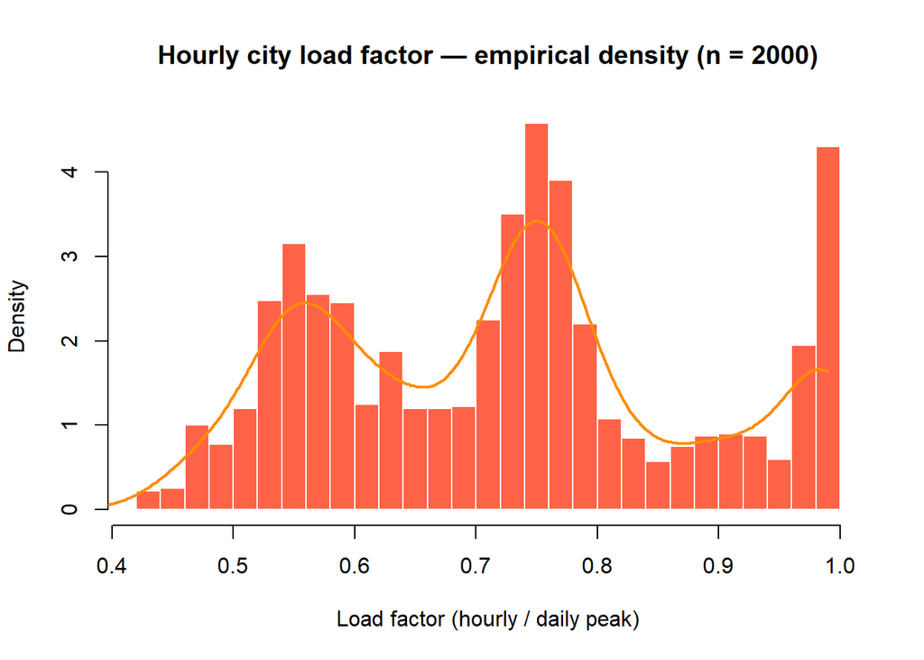

```r
hist(lf$load_factor, breaks = 35, freq = FALSE,
     col = "tomato", border = "white",
     xlab = "Load factor (hourly / daily peak)",
     main = "Hourly city load factor — empirical density (n = 2000)")
lines(density(lf$load_factor, from = 0.01, to = 0.99),
      col = "darkorange", lwd = 2)
```

# Task 1

Objective: Compare a single Beta vs Beta mixture model with $H = 1, 2, 3, 4, 5$, with model selection via WAIC

## Mathematical Formulation: Beta Mixture Model (BMM)

A **Beta Mixture Model** with $H$ components expresses the probability density function (PDF) of a continuous random variable $X$ (where $X \in (0,1)$) as a convex combination of $H$ distinct Beta distributions.

The overall density function is defined as:

$$f(x; \boldsymbol{\pi},
\boldsymbol{\alpha}, \boldsymbol{\beta}) = \sum_{h=1}^H \pi_h \cdot
\text{Beta}(x; \alpha_h, \beta_h)$$

### Constraints and Parameters

- **Mixture Weights (**$\pi_h$): Represent the probability of a data point belonging to component $h$. They must satisfy the following conditions:
  $$\sum_{h=1}^H \pi_h = 1 \quad
  \text{and} \quad \pi_h \ge 0 \quad \forall h \in \{1, \dots,
  H\}$$
- **Shape Parameters (**$\alpha_h, \beta_h$): Govern the geometry of each individual Beta density within the mixture. They must be strictly positive:
  $$\alpha_h > 0, \quad
  \beta_h > 0 \quad \forall h \in \{1, \dots, H\}$$

### Component Density Function

Each individual component $h$ is a standard Beta distribution with the following PDF:

$$\text{Beta}(x; \alpha_h, \beta_h) =
\frac{1}{\text{B}(\alpha_h, \beta_h)} x^{\alpha_h - 1} (1 - x)^{\beta_h
- 1}$$

Where $\text{B}(\alpha_h, \beta_h)$ is the **Beta Function**, which acts as a normalizing constant and is defined using the Gamma function ($\Gamma$):

$$\text{B}(\alpha_h, \beta_h) =
\frac{\Gamma(\alpha_h)\Gamma(\beta_h)}{\Gamma(\alpha_h + \beta_h)} =
\int_{0}^{1} t^{\alpha_h - 1}(1 - t)^{\beta_h - 1} dt$$

## Model Selection via WAIC (Widely Applicable Information Criterion)

To determine the optimal number of components $H \in \{1, \dots, 5\}$, we use **WAIC**, a fully Bayesian criterion that estimates the out-of-sample predictive accuracy. It is particularly suited for mixture models because it accounts for the entire posterior distribution rather than a single point estimate.

WAIC is defined as:

$$\text{WAIC} = -2 \cdot (\text{lppd} -
p_{\text{WAIC}})$$

Where: * $\text{lppd}$ is the **log pointwise predictive density**, which measures how well the model fits the observed data. * $p_{\text{WAIC}}$ is the **effective number of parameters**, acting as a penalty for model complexity to prevent overfitting.

### 1. Log Pointwise Predictive Density (lppd)

Given $n$ data points and $S$ posterior samples drawn from the MCMC chains, the $\text{lppd}$ is calculated by averaging the likelihood of each data point across all posterior samples, and then taking the log:

$$\text{lppd} = \sum_{i=1}^n \ln \left(
\frac{1}{S} \sum_{s=1}^S f(x_i; \boldsymbol{\theta}^s)
\right)$$

Where $f(x_i; \boldsymbol{\theta}^s)$ is the Beta Mixture density evaluated at data point $x_i$ using the parameters $\boldsymbol{\theta}^s = \{\boldsymbol{\pi}^s, \boldsymbol{\alpha}^s, \boldsymbol{\beta}^s\}$ from the $s$-th posterior draw.

### 2. Effective Number of Parameters ($p_{\text{WAIC}}$)

The penalty term computes the posterior variance of the log-likelihood for each data point individually, summing them up. This captures how sensitive the model is to the posterior uncertainty:

$$p_{\text{WAIC}} = \sum_{i=1}^n
\mathcal{V}_{s=1}^S \Big( \ln f(x_i; \boldsymbol{\theta}^s)
\Big)$$

Where $\mathcal{V}_{s=1}^S$ denotes the sample variance over the $S$ posterior simulations:

$$\mathcal{V}_{s=1}^S \Big( \ln f(x_i;
\boldsymbol{\theta}^s) \Big) = \frac{1}{S-1} \sum_{s=1}^S \left( \ln
f(x_i; \boldsymbol{\theta}^s) - \frac{1}{S}\sum_{j=1}^S \ln f(x_i;
\boldsymbol{\theta}^j) \right)^2$$

## JAGS Model

### The Bayesian Formulation with Latent Variables (JAGS Approach)

In practice, we do not know which component generated which data point. To solve this in a Bayesian framework using JAGS, we introduce a **latent discrete variable** $z_i$ for each observation $x_i$.

The variable $z_i \in \{1, \dots, H\}$ acts as a classification label or “indicator”, telling us which sub-population the $i$-th data point belongs to.

#### Hierarchical Model Structure

We define the model hierarchically as follows:

1. **Latent Assignment (**$z_i$):
   $$z_i
   \sim \text{Categorical}(\boldsymbol{\pi})$$
   This means each data point is randomly assigned to a component based on the probabilities defined by the mixture weights $\boldsymbol{\pi} = [\pi_1, \dots, \pi_H]$.
2. **Conditional Likelihood (**$x_i \mid z_i$):
   $$x_i \mid z_i \sim \text{Beta}(\alpha_{z_i},
   \beta_{z_i})$$
   Once the component $z_i$ is assigned, the actual data point $x_i$ is sampled from that specific Beta distribution.

#### Prior Distributions

To complete the Bayesian setup, we must specify prior distributions for all unknown parameters:

- **For the weights (**$\boldsymbol{\pi}$): We use a symmetric **Dirichlet distribution**, which is the natural conjugate prior for categorical probabilities that must sum to 1:
  $$\boldsymbol{\pi} \sim
  \text{Dirichlet}(\mathbf{1}_H)$$
  Where $\mathbf{1}_H = [1, 1, \dots, 1]$ of length $H$. This represents a flat, uninformative uniform prior over the probability simplex.
- **For the shape parameters (**$\alpha_h, \beta_h$): Since these parameters must be strictly positive, we assign an **Exponential distribution** with a small rate parameter $\lambda$:
  $$\alpha_h \sim \text{Exponential}(\lambda), \quad
  \beta_h \sim \text{Exponential}(\lambda) \quad \forall h \in \{1, \dots,
  H\}$$
  Setting $\lambda = 0.1$ ensures the prior is highly diffuse (weak), allowing the data to fully drive the posterior estimation.

## CODE

Importiamo i dati. Per la run *finale* usiamo tutti i 2000 dati; per i test rapidi basta mettere `use_subsample <- TRUE` (così non ci mettiamo ore a runnare). Fissiamo il seed per riproducibilità e teniamo `hour` allineato a `my_data` (servirà per il clustering su z).

```r
set.seed(123)

# RIPRODUCIBILITA' DI JAGS.
# set.seed() fissa solo l'RNG di R (subsample, jitter), NON il sampler interno
# di JAGS: per questo prima il WAIC (e quindi best_H) cambiava a ogni knit.
# Passando inits con .RNG.name/.RNG.seed per ogni catena, JAGS diventa
# completamente deterministico: stesso campionamento, stesso WAIC, stesso best_H.
make_inits <- function(n_chains, seed0 = 123) {
  lapply(seq_len(n_chains), function(c)
    list(.RNG.name = "base::Mersenne-Twister", .RNG.seed = seed0 + c))
}

use_subsample <- TRUE   # TRUE per test rapidi, FALSE per la run finale
n_sub <- 400

if (use_subsample) {
  idx <- sample(seq_len(nrow(lf)), n_sub)
} else {
  idx <- seq_len(nrow(lf))
}
lf_fit <- lf[idx, ]                 # sottoinsieme usato per il fit (con 'hour')

# TRUCCO PER JAGS:
# La Beta non è definita esattamente in 0 o 1 (log(0) è indefinito).
# Schiacciamo impercettibilmente i valori estremi appena dentro (0, 1).
my_data <- pmax(lf_fit$load_factor)
N <- length(my_data)
```

Then we define the JAGS models. Since is a bit tricky JAGS with the dimesionality we need two different definitions one for H1 and one parametric for the others.

The following code basically tells JAGS what likelihood and priors to use, so that it can run MCMC simulations and estimate the posterior distribution.

- The likelihood is defined as a Beta Mixture Mode.  
  We introduce a latent categorical indicator $Z_i$ to assign each observation $X_i$ to one of the $H$ components.
- We assign weakly informative priors to all unknown parameters. Specifically, a symmetric Dirichlet prior is placed on the mixture weights $\boldsymbol{\pi}$ to ensure they sum up to 1.
- For the shape parameters $\alpha_h$ and $\beta_h$, we use Exponential priors with a small rate parameter ($\lambda = 0.1$). This choice ensures the parameters remain strictly positive while keeping the prior diffuse and uninformative.

```r
# Model with H=1
jags_model_H1 <- "
model {
  for (i in 1:N) {
    x[i] ~ dbeta(alpha, beta)
    # Note that with a single component the marginal log-lik is the log density of the Beta
    log_lik[i] <- logdensity.beta(x[i], alpha, beta)
  }
  alpha ~ dexp(0.1)
  beta  ~ dexp(0.1)
}
"

# Model for H > 1 (Beta Mixture Model with Latent Variable Z)
jags_model_mix <- "
model {
  # Used from JAGS gibb's sampler
  for (i in 1:N) {
    z[i] ~ dcat(pi_weights[1:H])
    x[i] ~ dbeta(alpha[z[i]], beta[z[i]])

    # Log-lik MARGINALE per WAIC/LOO: log sum_h pi_h * Beta(x_i | a_h, b_h),
    # con la latente z integrata via. Calcolata con log-sum-exp per stabilita'
    # numerica (exp/log/max sono funzioni scalari in JAGS).
    for (h in 1:H) {
      lcomp[i, h] <- log(pi_weights[h]) + logdensity.beta(x[i], alpha[h], beta[h])
    }
    mx[i] <- max(lcomp[i, 1:H])
    for (h in 1:H) {
      e[i, h] <- exp(lcomp[i, h] - mx[i])
    }
    log_lik[i] <- mx[i] + log(sum(e[i, 1:H]))
  }


  # Uninformative Dirichlet prior for mixture weights
  pi_weights[1:H] ~ ddirch(ones[1:H])

  # Weakly informative Exponential priors for shape parameters
  for (h in 1:H) {
    alpha[h] ~ dexp(0.1)
    beta[h]  ~ dexp(0.1)
  }
}
"
```

Helper per il WAIC.

**Punto chiave.** Per una mistura il WAIC va calcolato sulla likelihood **marginale** dell’osservazione, integrando via la latente $z$:
$$\log p(x_i \mid \theta^{(s)}) = \log \sum_{h=1}^H
\pi_h^{(s)}\,\text{Beta}(x_i \mid \alpha_h^{(s)},
\beta_h^{(s)}).$$
Usare invece la log-densità *condizionata* alla $z_i$ pescata a quel passo ($\log\text{Beta}(x_i\mid\alpha_{z_i},\beta_{z_i})$) risponde a un’altra domanda predittiva, gonfia $p_{\text{WAIC}}$ e premia troppi componenti. Come nel lab `03_mixtures`, calcoliamo `log_lik[i]` **dentro JAGS** con il trucco log-sum-exp (stabile numericamente) e lo monitoriamo; qui l’helper si limita a impilare i campioni nella forma $[S \times N]$ che `loo::waic` si aspetta. Vantaggio collaterale: la densità marginale è invariante per permutazione delle etichette, quindi questo WAIC è **immune al label switching**.

```r
# Riformatta la log_lik monitorata da jags.samples (mcarray [N, iter, chains])
# nella matrice [S, N] richiesta da loo::waic / loo::loo.
loglik_to_matrix <- function(loglik_samples) {
  ll <- aperm(loglik_samples, c(2, 3, 1))   # [iter, chains, N]
  S  <- dim(ll)[1] * dim(ll)[2]             # iter * chains
  n  <- dim(ll)[3]
  matrix(ll, nrow = S, ncol = n)
}

# Oggetto WAIC completo (Estimate + SE + p_waic), non solo lo scalare:
# serve per la tabella con SE e per loo_compare (stile lab 03_mixtures).
waic_from_loglik <- function(loglik_samples) waic(loglik_to_matrix(loglik_samples))

# Scalare WAIC (comodo dove serve solo il numero, es. plot/which.min).
compute_waic_from_loglik <- function(loglik_samples)
  waic_from_loglik(loglik_samples)$estimates["waic", "Estimate"]

# Una riga della tabella di confronto: ELPD, p_eff (= p_waic, n. effettivo di
# parametri), WAIC e relativo SE. Riproduce 'ic_row' del lab in base R.
ic_row <- function(w, nm) {
  e <- w$estimates
  data.frame(Model = nm,
             ELPD  = round(e["elpd_waic", "Estimate"], 1),
             p_eff = round(e["p_waic",    "Estimate"], 1),
             WAIC  = round(e["waic",      "Estimate"], 1),
             SE    = round(e["waic",      "SE"],       1))
}

# Parsimonious model selection within one standard error of the best WAIC.
# A bare which.min always chases the lowest point estimate, even when the
# gap to a simpler model is smaller than the sampling noise of the WAIC.
# Instead we take the lowest WAIC, build a threshold one SE above it, and
# among all candidates whose WAIC falls below that threshold we return the
# simplest one (smallest complexity value, e.g. fewest components/harmonics).
# Returns the index of the chosen candidate within the supplied vectors.
select_parsimonious <- function(waic_values, waic_se, complexity, n_se = 1) {
  best      <- which.min(waic_values)
  threshold <- waic_values[best] + n_se * waic_se[best]
  tied      <- which(waic_values <= threshold)
  tied[which.min(complexity[tied])]
}
```

Now its time to fit thoose models.

We do this with the following hyperparams for the following reasons:

- n chains = 2  
  This because maybe the markow chain gets stuck somewhere on a local max and we get biased data. With 2 jags start in 2 crazy different points => less probability to get stuck.  
  Ideally we would use 3/4 in the officials run
- burnin = 1000  
  Standard burnin
- iterations = 2000

H1

```r
cat("Fitting Model H = 1...\n")
```

```
## Fitting Model H = 1...
```

```r
jags_data_H1 <- list(x = my_data, N = N)
model_H1 <- jags.model(textConnection(jags_model_H1), data = jags_data_H1, inits = make_inits(2), n.chains = 2, quiet = TRUE)

# Burn-in phase
update(model_H1, n.iter = 1000)

# Posterior sampling
samples_H1 <- jags.samples(model_H1, variable.names = c("alpha", "beta", "log_lik"), n.iter = 2000)

waic_H1 <- compute_waic_from_loglik(samples_H1$log_lik)
cat("WAIC for H = 1:", waic_H1, "\n")
```

```
## WAIC for H = 1: -327.7879
```

H2

```r
cat("Fitting Model H = 2...\n")
```

```
## Fitting Model H = 2...
```

```r
jags_data_H2 <- list(x = my_data, N = N, H = 2, ones = rep(1, 2))
model_H2 <- jags.model(textConnection(jags_model_mix), data = jags_data_H2, inits = make_inits(2), n.chains = 2, quiet = TRUE)

update(model_H2, n.iter = 1000)
samples_H2 <- jags.samples(model_H2, variable.names = c("pi_weights", "alpha", "beta", "log_lik"), n.iter = 2000)

waic_H2 <- compute_waic_from_loglik(samples_H2$log_lik)
cat("WAIC for H = 2:", waic_H2, "\n")
```

```
## WAIC for H = 2: -499.4394
```

H3

```r
cat("Fitting Model H = 3...\n")
```

```
## Fitting Model H = 3...
```

```r
jags_data_H3 <- list(x = my_data, N = N, H = 3, ones = rep(1, 3))
model_H3 <- jags.model(textConnection(jags_model_mix), data = jags_data_H3, inits = make_inits(2), n.chains = 2, quiet = TRUE)

update(model_H3, n.iter = 1000)
samples_H3 <- jags.samples(model_H3, variable.names = c("pi_weights", "alpha", "beta", "log_lik"), n.iter = 2000)

waic_H3 <- compute_waic_from_loglik(samples_H3$log_lik)
cat("WAIC for H = 3:", waic_H3, "\n")
```

```
## WAIC for H = 3: -567.0962
```

H4

```r
cat("Fitting Model H = 4...\n")
```

```
## Fitting Model H = 4...
```

```r
jags_data_H4 <- list(x = my_data, N = N, H = 4, ones = rep(1, 4))
model_H4 <- jags.model(textConnection(jags_model_mix), data = jags_data_H4, inits = make_inits(2), n.chains = 2, quiet = TRUE)

update(model_H4, n.iter = 1000)
samples_H4 <- jags.samples(model_H4, variable.names = c("pi_weights", "alpha", "beta", "log_lik"), n.iter = 2000)

waic_H4 <- compute_waic_from_loglik(samples_H4$log_lik)
cat("WAIC for H = 4:", waic_H4, "\n")
```

```
## WAIC for H = 4: -564.599
```

H5

```r
cat("Fitting Model H = 5...\n")
```

```
## Fitting Model H = 5...
```

```r
jags_data_H5 <- list(x = my_data, N = N, H = 5, ones = rep(1, 5))
model_H5 <- jags.model(textConnection(jags_model_mix), data = jags_data_H5, inits = make_inits(2), n.chains = 2, quiet = TRUE)

update(model_H5, n.iter = 1000)
samples_H5 <- jags.samples(model_H5, variable.names = c("pi_weights", "alpha", "beta", "log_lik"), n.iter = 2000)

waic_H5 <- compute_waic_from_loglik(samples_H5$log_lik)
cat("WAIC for H = 5:", waic_H5, "\n")
```

```
## WAIC for H = 5: -566.674
```

**Reading the WAIC, not just its minimum.** A single WAIC number hides its sampling uncertainty: the WAIC of each model carries a standard error (SE), and two models whose WAIC differ by less than roughly $1$–$2$ SE are statistically *indistinguishable*. We therefore report, as the lab does, the full table with `ELPD`, the effective number of parameters `p_eff` ($= p_{\text{WAIC}}$, the complexity penalty), `WAIC` and its `SE`, and we run `loo_compare`, which ranks the models and gives the pairwise `elpd_diff` together with its `se_diff`. When several $H$ are tied within the noise, the honest choice is the **most parsimonious** among them rather than the bare `which.min`.

```r
# Full WAIC objects (Estimate, SE, p_eff) reusing the monitored log_lik
waic_objs <- list(
  "H=1" = waic_from_loglik(samples_H1$log_lik),
  "H=2" = waic_from_loglik(samples_H2$log_lik),
  "H=3" = waic_from_loglik(samples_H3$log_lik),
  "H=4" = waic_from_loglik(samples_H4$log_lik),
  "H=5" = waic_from_loglik(samples_H5$log_lik)
)

# Precise vectors for plotting / selection (unrounded)
all_waic_values <- sapply(waic_objs, function(w) w$estimates["waic", "Estimate"])
waic_se         <- sapply(waic_objs, function(w) w$estimates["waic", "SE"])

# Comparison table: ELPD, p_eff, WAIC, SE
waic_table <- do.call(rbind, Map(ic_row, waic_objs, names(waic_objs)))
cat("--- MODEL SELECTION: WAIC with standard errors ---\n")
```

```
## --- MODEL SELECTION: WAIC with standard errors ---
```

```r
print(waic_table, row.names = FALSE)
```

```
##  Model  ELPD p_eff   WAIC   SE
##    H=1 163.9   2.7 -327.8 14.4
##    H=2 249.7   3.9 -499.4 20.5
##    H=3 283.5   6.2 -567.1 22.6
##    H=4 282.3   6.6 -564.6 22.1
##    H=5 283.3   6.4 -566.7 22.4
```

```r
# Pairwise comparison on the predictive scale (elpd_diff +/- se_diff)
cat("\n--- loo_compare (differences vs the best model) ---\n")
```

```
##
## --- loo_compare (differences vs the best model) ---
```

```r
print(loo_compare(waic_objs))
```

```
##     elpd_diff se_diff
## H=3    0.0       0.0
## H=5   -0.2       0.4
## H=4   -1.2       0.5
## H=2  -33.8       6.7
## H=1 -119.7      12.8
```

```r
lowest_H <- which.min(all_waic_values)
chosen_H <- select_parsimonious(all_waic_values, waic_se, complexity = 1:5)
cat("\n>>> Lowest-WAIC model: H =", lowest_H, "components\n")
```

```
##
## >>> Lowest-WAIC model: H = 3 components
```

```r
cat(">>> Parsimonious choice (within 1 SE): H =", chosen_H, "components <<<\n")
```

```
## >>> Parsimonious choice (within 1 SE): H = 3 components <<<
```

```r
cat("    (models within 1 SE of the lowest WAIC are statistically tied;\n",
    "    we keep the simplest among them rather than the bare which.min.)\n")
```

```
##     (models within 1 SE of the lowest WAIC are statistically tied;
##      we keep the simplest among them rather than the bare which.min.)
```

## Now visualize some data.

Waic value over the all the fittings.

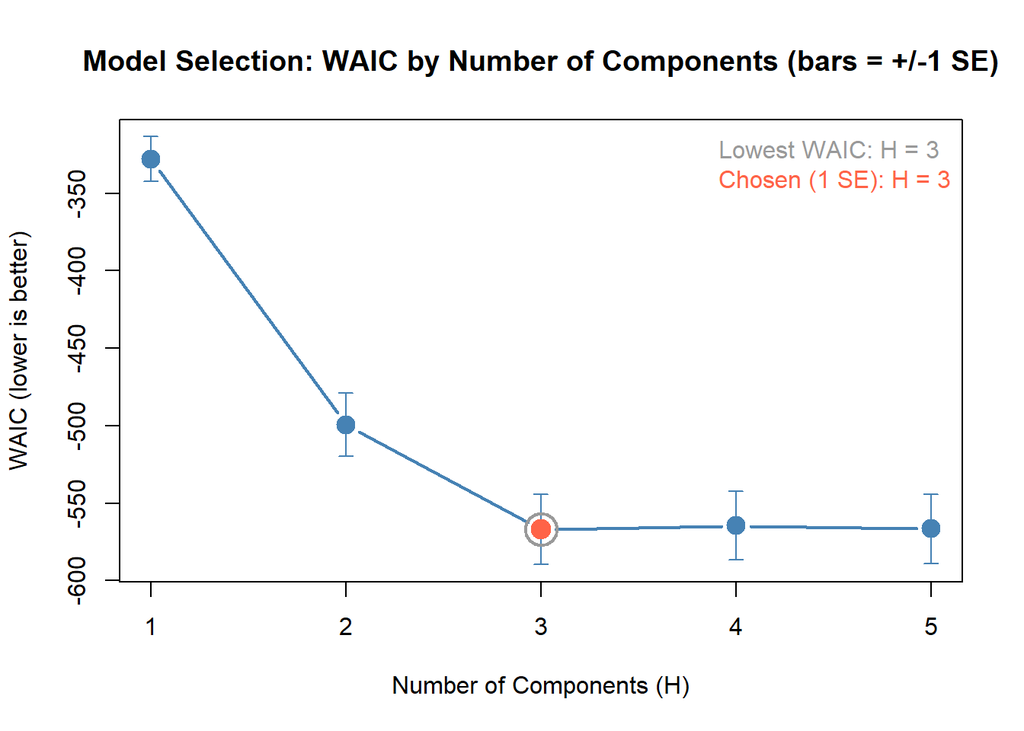

```r
# WAIC vs H with +/-1 SE error bars: the bars show the elbow and the
# ambiguity honestly (same idea as the lab's error-bar plot).
ylim_waic <- range(c(all_waic_values - waic_se, all_waic_values + waic_se))
plot(1:5, all_waic_values,
     type = "b", pch = 19, cex = 1.5, col = "steelblue", lwd = 2,
     ylim = ylim_waic,
     xlab = "Number of Components (H)",
     ylab = "WAIC (lower is better)",
     main = "Model Selection: WAIC by Number of Components (bars = +/-1 SE)",
     xaxt = "n")
axis(1, at = 1:5)

# +/-1 SE error bars
arrows(1:5, all_waic_values - waic_se, 1:5, all_waic_values + waic_se,
       angle = 90, code = 3, length = 0.05, col = "steelblue")

# Parsimonious choice: simplest model within 1 SE of the lowest WAIC
lowest_H <- which.min(all_waic_values)
best_H   <- select_parsimonious(all_waic_values, waic_se, complexity = 1:5)
points(lowest_H, all_waic_values[lowest_H], col = "gray60", pch = 1, cex = 3, lwd = 2)
points(best_H,   all_waic_values[best_H],   col = "tomato", pch = 19, cex = 1.8)
legend("topright",
       legend = c(paste("Lowest WAIC: H =", lowest_H),
                  paste("Chosen (1 SE): H =", best_H)),
       text.col = c("gray60", "tomato"), bty = "n")
```

Lets see how the different models compare with the data

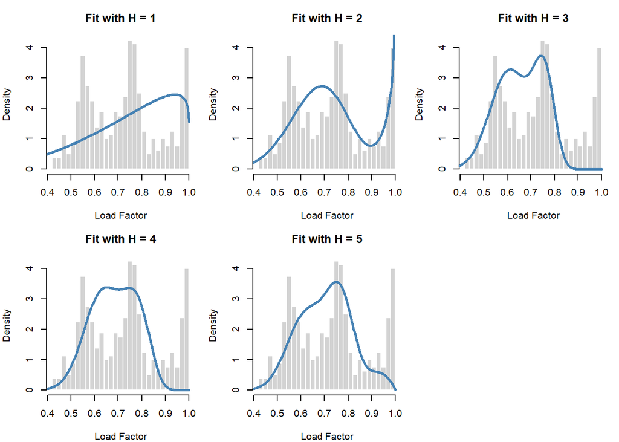

```r
# Group all samples into a list for easy looping
all_samples <- list(samples_H1, samples_H2, samples_H3, samples_H4, samples_H5)

# Set up a 2x3 grid for plotting
par(mfrow = c(2, 3), mar = c(4, 4, 3, 1))

x_seq <- seq(0.001, 0.999, length.out = 500)

for (h in 1:5) {
  # 1. Extract posterior means for the current H
  current_samples <- all_samples[[h]]

  if (h == 1) {
    est_pi <- 1
    est_alpha <- mean(current_samples$alpha)
    est_beta <- mean(current_samples$beta)
  } else {
    est_pi <- apply(current_samples$pi_weights, 1, mean)
    est_alpha <- apply(current_samples$alpha, 1, mean)
    est_beta <- apply(current_samples$beta, 1, mean)
  }

  # 2. Draw the empirical histogram
  hist(my_data, breaks = 30, freq = FALSE,
       col = "lightgray", border = "white",
       xlab = "Load Factor", main = paste("Fit with H =", h))

  # 3. Calculate and draw the overall mixture density
  total_density <- rep(0, 500)
  for (c in 1:h) {
    total_density <- total_density + est_pi[c] * dbeta(x_seq, est_alpha[c], est_beta[c])
  }
  lines(x_seq, total_density, col = "steelblue", lwd = 2.5)
}

# Reset the plotting layout to standard
par(mfrow = c(1, 1))
```

The optimal model:

```r
# Extract samples of the winning model
best_samples <- all_samples[[best_H]]

if (best_H == 1) {
  best_pi <- 1
  best_alpha <- mean(best_samples$alpha)
  best_beta <- mean(best_samples$beta)
} else {
  best_pi <- apply(best_samples$pi_weights, 1, mean)
  best_alpha <- apply(best_samples$alpha, 1, mean)
  best_beta <- apply(best_samples$beta, 1, mean)
}

# Print the final parameters to the console
cat("\n--- POSTERIOR MEANS OF THE BEST MODEL (H =", best_H, ") ---\n")
```

```
##
## --- POSTERIOR MEANS OF THE BEST MODEL (H = 3 ) ---
```

```r
final_params <- data.frame(Component = 1:best_H, Weight_Pi = best_pi, Alpha = best_alpha, Beta = best_beta)
print(round(final_params, 3))
```

```
##   Component Weight_Pi  Alpha   Beta
## 1         1     0.314 23.596 15.264
## 2         2     0.373 66.034 22.151
## 3         3     0.314 25.089 16.975
```

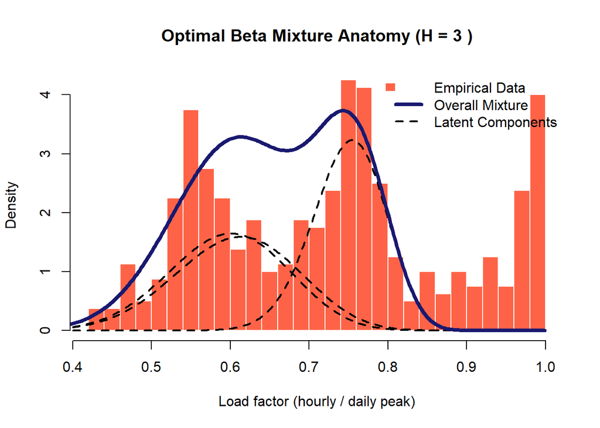

```r
# Draw the main histogram
hist(my_data, breaks = 40, freq = FALSE,
     col = "tomato", border = "white",
     xlab = "Load factor (hourly / daily peak)",
     main = paste("Optimal Beta Mixture Anatomy (H =", best_H, ")"))

# Calculate total density and individual components
total_density <- rep(0, 500)

for (c in 1:best_H) {
  # Density of the single component scaled by its weight
  comp_density <- best_pi[c] * dbeta(x_seq, best_alpha[c], best_beta[c])
  total_density <- total_density + comp_density

  # Draw the individual component (dashed line)
  if (best_H > 1) {
    lines(x_seq, comp_density, col = "black", lty = 2, lwd = 2)
  }
}

# Draw the overall mixture density (thick solid line)
lines(x_seq, total_density, col = "midnightblue", lwd = 4)

# Add Legend
if (best_H > 1) {
  legend("topright",
         legend = c("Empirical Data", "Overall Mixture", "Latent Components"),
         fill = c("tomato", NA, NA),
         border = c("white", NA, NA),
         col = c(NA, "midnightblue", "black"),
         lty = c(NA, 1, 2),
         lwd = c(NA, 4, 2),
         bty = "n")
}
```

## MCMC Diagnostics: The Label Switching Problem

In a mixture model the $H$ components are **exchangeable**: permuting their labels leaves the joint likelihood unchanged, so the posterior has up to $H!$ equivalent modes — one for each relabelling of the same solution. When two MCMC chains independently explore different permutations, the raw parameter traces cross and swap between iterations, a phenomenon known as **label switching**. Naively averaging parameters across such chains would blend draws from different permutations, producing meaningless component summaries.

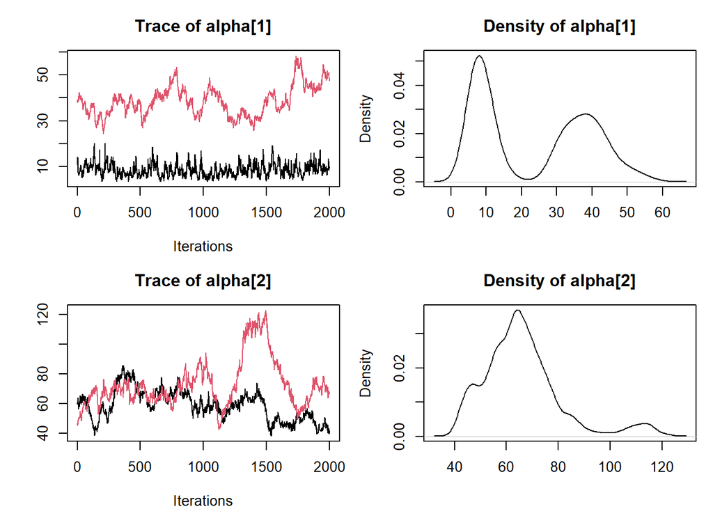

```r
# MCMC DIAGNOSTICS: TRACE E DENSITY PER ALPHA, BETA E WEIGHTS
# Estraiamo i campioni grezzi per il modello migliore (es. H = 4)
raw_samples <- all_samples[[best_H]]

# Creiamo le matrici grezze [Componente, Iterazioni] SENZA alcun ordinamento
raw_pi_mat    <- matrix(raw_samples$pi_weights, nrow = best_H)
raw_alpha_mat <- matrix(raw_samples$alpha, nrow = best_H)
raw_beta_mat  <- matrix(raw_samples$beta, nrow = best_H)

# Estraiamo gli array 3D originali restituiti da jags.samples
# Dimensioni: [Componente, Iterazione, Catena]
alpha_array <- raw_samples$alpha
beta_array  <- raw_samples$beta
pi_array <- raw_samples$pi_weights

# Ricaviamo numero di iterazioni e di catene
n_iter   <- dim(alpha_array)[2]
n_chains <- dim(alpha_array)[3]

# Colori standard usati da 'coda' per le catene (1=nero, 2=rosso, 3=verde, ecc.)
chain_colors <- 1:n_chains

# ---------------------------------------------------------------------
# DIAGNOSTICA PER ALPHA
# ---------------------------------------------------------------------
# Layout: 2 componenti per pagina (Trace a sx, Density a dx). Cosi' knitr emette
# piu' immagini leggibili invece di schiacciare tutti gli H componenti in una.
par(mfrow = c(2, 2), mar = c(4, 4, 3, 1))

for (h in 1:best_H) {
  # Calcoliamo i limiti dell'asse Y per includere tutte le catene senza tagliare i picchi
  y_lims <- range(alpha_array[h, , ])

  # 1. Trace plot: Disegniamo prima la Catena 1
  plot(1:n_iter, alpha_array[h, , 1], type = "l", col = chain_colors[1],
       ylim = y_lims, xlab = "Iterations", ylab = "",
       main = paste0("Trace of alpha[", h, "]"))

  # Sovrapponiamo le altre catene con colori diversi
  if (n_chains > 1) {
    for (c in 2:n_chains) {
      lines(1:n_iter, alpha_array[h, , c], col = chain_colors[c])
    }
  }

  # 2. Density plot: calcolato su tutti i campioni uniti (raw_alpha_mat)
  plot(density(raw_alpha_mat[h, ]),
       main = paste0("Density of alpha[", h, "]"),
       xlab = "", ylab = "Density")
}
```

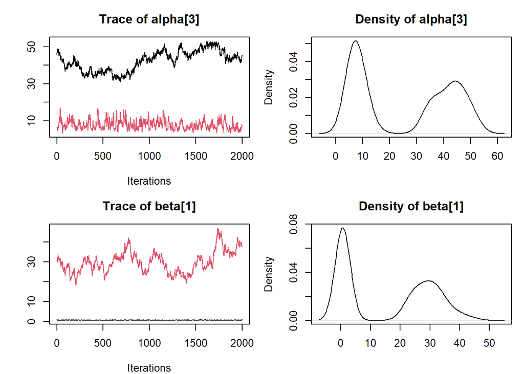

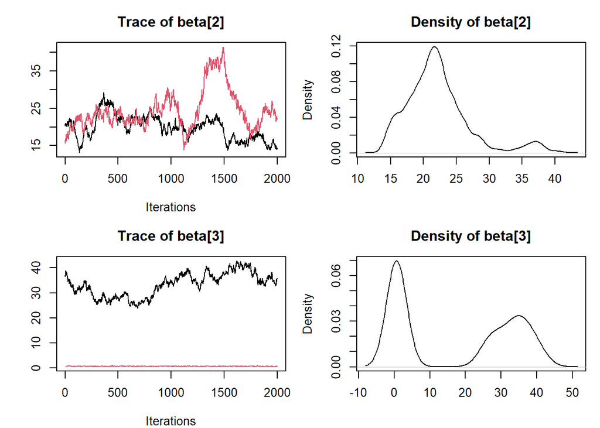

```r
# ---------------------------------------------------------------------
# DIAGNOSTICA PER BETA
# ---------------------------------------------------------------------


for (h in 1:best_H) {
  y_lims <- range(beta_array[h, , ])

  # 1. Trace plot: Catena 1
  plot(1:n_iter, beta_array[h, , 1], type = "l", col = chain_colors[1],
       ylim = y_lims, xlab = "Iterations", ylab = "",
       main = paste0("Trace of beta[", h, "]"))

  # Sovrapponiamo le altre catene
  if (n_chains > 1) {
    for (c in 2:n_chains) {
      lines(1:n_iter, beta_array[h, , c], col = chain_colors[c])
    }
  }

  # 2. Density plot
  plot(density(raw_beta_mat[h, ]),
       main = paste0("Density of beta[", h, "]"),
       xlab = "", ylab = "Density")
}
```

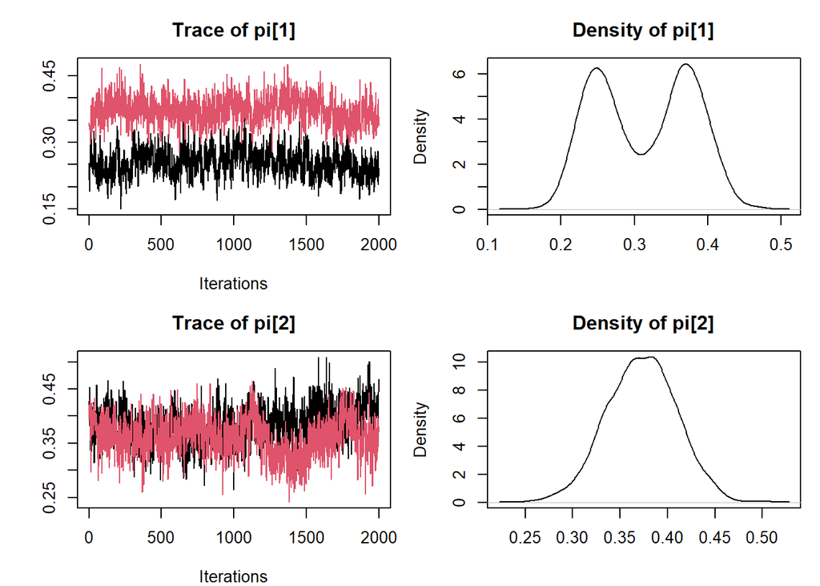

```r
# ---------------------------------------------------------------------
# DIAGNOSTICA PER PI
# ---------------------------------------------------------------------

for (h in 1:best_H) {
  # I pesi sono vincolati tra 0 e 1, ma usiamo il range effettivo per non tagliare il dettaglio
  y_lims <- range(pi_array[h, , ])

  # 1. Trace plot: Disegniamo prima la Catena 1
  plot(1:n_iter, pi_array[h, , 1], type = "l", col = chain_colors[1],
       ylim = y_lims, xlab = "Iterations", ylab = "",
       main = paste0("Trace of pi[", h, "]"))

  # Sovrapponiamo le altre catene
  if (n_chains > 1) {
    for (c in 2:n_chains) {
      lines(1:n_iter, pi_array[h, , c], col = chain_colors[c])
    }
  }

  # 2. Density plot: calcolato sulla matrice unita (raw_pi_mat)
  plot(density(raw_pi_mat[h, ]),
       main = paste0("Density of pi[", h, "]"),
       xlab = "", ylab = "Density")
}
```

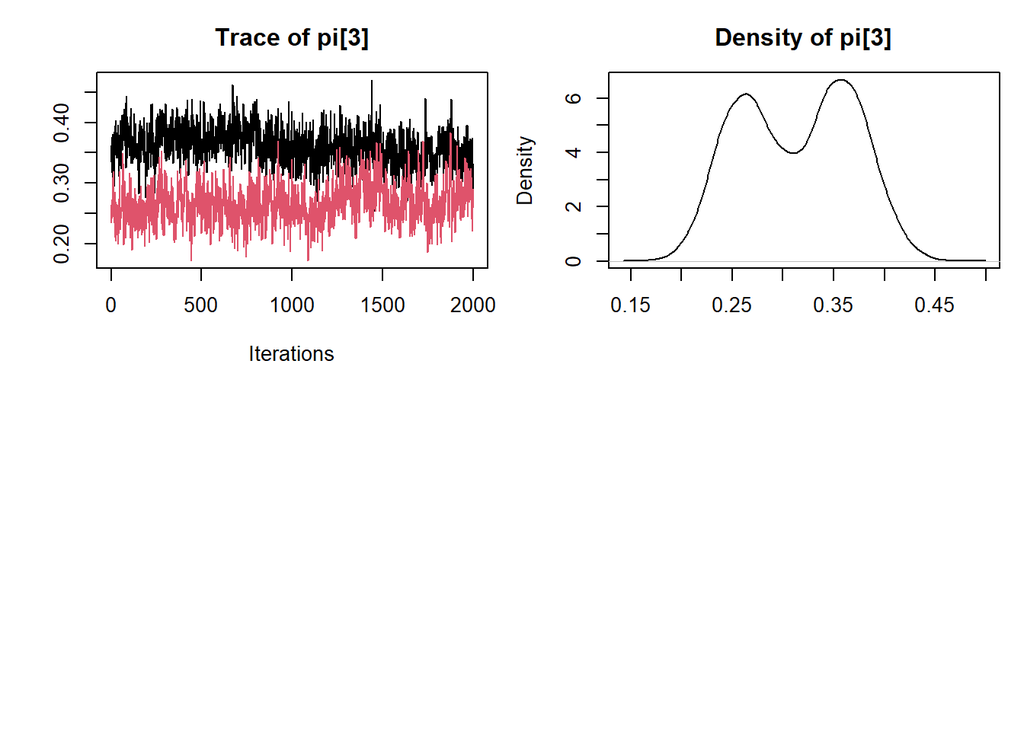

```r
# Ripristino del layout di default
par(mfrow = c(1, 1))
```

```r
# Function to calculate R-hat and return a clean, structured data frame including mixture weights
calculate_rhat_table <- function(alpha_array, beta_array, pi_array, best_H, n_chains) {

  # Vectors to store the point estimates
  rhat_alpha <- numeric(best_H)
  rhat_beta  <- numeric(best_H)
  rhat_pi    <- numeric(best_H)

  for (h in 1:best_H) {
    # --- Gelman-Rubin Diagnostic for Alpha ---
    chain_list_alpha <- list()
    for (c in 1:n_chains) {
      chain_list_alpha[[c]] <- mcmc(alpha_array[h, , c])
    }
    gr_alpha <- gelman.diag(as.mcmc.list(chain_list_alpha), autoburnin = FALSE)
    rhat_alpha[h] <- gr_alpha$psrf[1, 1] # Extract Point Estimate

    # --- Gelman-Rubin Diagnostic for Beta ---
    chain_list_beta <- list()
    for (c in 1:n_chains) {
      chain_list_beta[[c]] <- mcmc(beta_array[h, , c])
    }
    gr_beta <- gelman.diag(as.mcmc.list(chain_list_beta), autoburnin = FALSE)
    rhat_beta[h] <- gr_beta$psrf[1, 1] # Extract Point Estimate

    # --- Gelman-Rubin Diagnostic for Pi (Weights) ---
    chain_list_pi <- list()
    for (c in 1:n_chains) {
      chain_list_pi[[c]] <- mcmc(pi_array[h, , c])
    }
    gr_pi <- gelman.diag(as.mcmc.list(chain_list_pi), autoburnin = FALSE)
    rhat_pi[h] <- gr_pi$psrf[1, 1] # Extract Point Estimate
  }

  # 1. Generate clean variable names dynamically
  alpha_names <- paste0("alpha[", 1:best_H, "]")
  beta_names  <- paste0("beta[", 1:best_H, "]")
  pi_names    <- paste0("pi[", 1:best_H, "]")

  # 2. Assemble everything into a single vertically aligned data frame
  rhat_table <- data.frame(
    Variable = c(alpha_names, beta_names, pi_names),
    Raw_R_hat = round(c(rhat_alpha, rhat_beta, rhat_pi), 4)
  )

  return(rhat_table)
}

# --- EXECUTION ---
# Call the function passing the 3D raw sample arrays from JAGS (including pi_weights)
rhat_table_output <- calculate_rhat_table(raw_samples$alpha,
                                          raw_samples$beta,
                                          raw_samples$pi_weights,
                                          best_H,
                                          n_chains)

# Print the table without row numbers for a cleaner layout
print(rhat_table_output, row.names = FALSE)
```

```
##  Variable Raw_R_hat
##  alpha[1]    7.4822
##  alpha[2]    1.5945
##  alpha[3]   10.0439
##   beta[1]    9.4601
##   beta[2]    1.5952
##   beta[3]   12.0103
##     pi[1]    4.8558
##     pi[2]    1.2277
##     pi[3]    3.9067
```

The traces show the characteristic label-switching signature: chains running on separate tracks that occasionally cross, and multimodal marginal densities for each raw component parameter. The $\hat{R}$ values in the table above, several of which exceed the conventional 1.10 threshold, formally confirm this instability. At this point two explanations are possible: the chains genuinely failed to mix and explore the posterior, or the high $\hat{R}$ is a statistical artifact caused by the chains sampling from different — but equivalent — label permutations of a well-mixed sampler.

```r
# 1. Estraiamo l'array della log-likelihood dal modello JAGS
# Dimensioni: [N_osservazioni, Iterazioni, Catene]
loglik_array <- raw_samples$log_lik

n_iter   <- dim(loglik_array)[2]
n_chains <- dim(loglik_array)[3]

# 2. Sommiamo la log-likelihood di tutte le N osservazioni per ottenere la Log-Likelihood Globale
# La funzione apply con MARGIN = c(2, 3) somma sulle righe, restituendo una matrice [Iterazioni, Catene]
global_loglik <- apply(loglik_array, c(2, 3), sum)

# 3. Convertiamo la matrice in una lista MCMC compatibile con la libreria coda
loglik_chains <- list()
for (c in 1:n_chains) {
  # Estraiamo la colonna corrispondente alla catena 'c'
  loglik_chains[[c]] <- mcmc(global_loglik[, c])
}
loglik_mcmc_list <- as.mcmc.list(loglik_chains)

# 4. Calcolo della diagnostica di convergenza
rhat_loglik <- gelman.diag(loglik_mcmc_list, autoburnin = FALSE)$psrf[1, 1]
ess_loglik  <- effectiveSize(loglik_mcmc_list)

# 5. Creazione della tabella pulita per il report
likelihood_diagnostic_table <- data.frame(
  Metric = c("R-hat ", "ESS  "),
  Value  = c(round(rhat_loglik, 4), round(ess_loglik, 2))
)

# Stampa finale
cat("Likelihood Convergence Diagnostic (Permutation-Invariant Scale)\n\n")
```

```
## Likelihood Convergence Diagnostic (Permutation-Invariant Scale)
```

```r
print(likelihood_diagnostic_table, row.names = FALSE)
```

```
##  Metric    Value
##  R-hat    1.0207
##   ESS   109.4900
```

To restore parameter identifiability for reporting, we apply a **post-hoc re-labelling**: at each MCMC draw we sort the $H$ components by their theoretical Beta mean,

$$\mathbb{E}[X_h] =
\frac{\alpha_h}{\alpha_h + \beta_h},$$

from smallest to largest. This criterion is the natural choice because $\mathbb{E}[X_h]$ is the “location” of component $h$ on the $(0,1)$ interval: it identifies whether a component captures low, medium, or high load-factor observations regardless of which numeric label JAGS happened to assign at that step. After re-ordering, “Component 1” consistently refers to the lowest-mean Beta across all draws and chains, making per-component summaries comparable. This post-hoc step does not alter the fit: the mixture density and the WAIC are unchanged; it only resolves the label ambiguity for interpretation.

```r
best_samples <- all_samples[[best_H]]

# Extract matrices [Components, Total MCMC Samples]
pi_mat <- matrix(best_samples$pi_weights, nrow = best_H)
alpha_mat <- matrix(best_samples$alpha, nrow = best_H)
beta_mat <- matrix(best_samples$beta, nrow = best_H)

S_totale <- ncol(pi_mat)
x_seq <- seq(0.001, 0.999, length.out = 500)

# Create an array to store the curves for each component across all samples
# Dimensions: [Component, MCMC Sample, X-axis point]
component_curves <- array(0, dim = c(best_H, S_totale, length(x_seq)))

cat("Sorting MCMC chains and calculating posterior densities...\n")
```

```
## Sorting MCMC chains and calculating posterior densities...
```

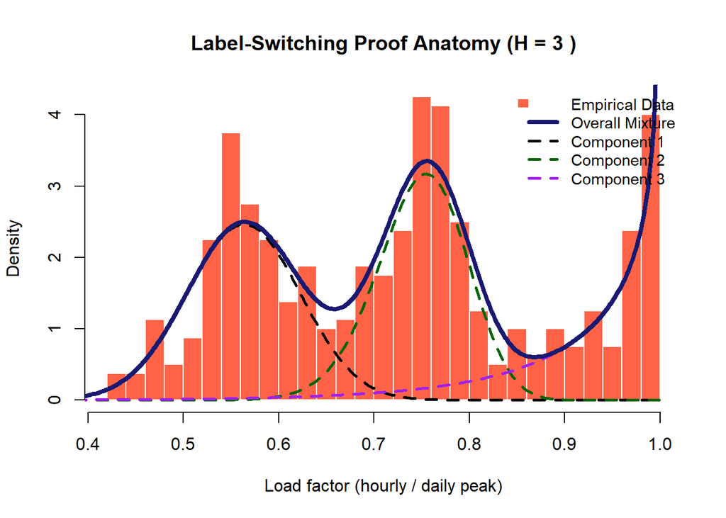

```r
for (s in 1:S_totale) {

  # 1. Calculate the theoretical mean of each Beta component at this step
  # Formula: Mean = alpha / (alpha + beta)
  beta_means <- alpha_mat[, s] / (alpha_mat[, s] + beta_mat[, s])

  # 2. Sort the components from left (smallest mean) to right (largest mean)
  # This COMPLETELY SOLVES the label switching problem for visualization!
  ordered_indices <- order(beta_means)

  # 3. Calculate the density for each sorted component
  for (h in 1:best_H) {
    idx <- ordered_indices[h] # The true index of the h-th component from the left

    # Calculate density scaled by its mixture weight
    density_h <- pi_mat[idx, s] * dbeta(x_seq, alpha_mat[idx, s], beta_mat[idx, s])

    # Store it
    component_curves[h, s, ] <- density_h
  }
}

# ------------------------------------------------------------------------------
# AVERAGE THE CURVES
# Now we can safely average the densities because Component 1 is ALWAYS the leftmost
# ------------------------------------------------------------------------------
final_components <- apply(component_curves, c(1, 3), mean)
final_overall_mixture <- colSums(final_components)

# ------------------------------------------------------------------------------
# PLOTTING
# ------------------------------------------------------------------------------
# Draw the empirical histogram
hist(my_data, breaks = 40, freq = FALSE,
     col = "tomato", border = "white",
     xlab = "Load factor (hourly / daily peak)",
     main = paste("Label-Switching Proof Anatomy (H =", best_H, ")"))

# Draw the individual sorted components (dashed lines)
colors_for_components <- c("black", "darkgreen", "purple", "darkorange", "brown")
for (h in 1:best_H) {
  lines(x_seq, final_components[h, ], col = colors_for_components[h], lty = 2, lwd = 2.5)
}

# Draw the overall mixture density (thick solid line)
lines(x_seq, final_overall_mixture, col = "midnightblue", lwd = 4)

# Add Legend
legend_labels <- c("Empirical Data", "Overall Mixture", paste("Component", 1:best_H))
legend_colors <- c(NA, "midnightblue", colors_for_components[1:best_H])
legend_lines <- c(NA, 1, rep(2, best_H))
legend_widths <- c(NA, 4, rep(2.5, best_H))

legend("topright",
       legend = legend_labels,
       fill = c("tomato", rep(NA, best_H + 1)),
       border = c("white", rep(NA, best_H + 1)),
       col = legend_colors,
       lty = legend_lines,
       lwd = legend_widths,
       bty = "n",
       cex = 0.9)
```

single distr visualization:

```r
# ---- Componenti Beta separati, con i loro valori --------------------------
best_samples <- all_samples[[best_H]]

# Parametri come matrici [H, S]  (S = iterazioni * catene)
pi_mat    <- matrix(best_samples$pi_weights, nrow = best_H)
alpha_mat <- matrix(best_samples$alpha,      nrow = best_H)
beta_mat  <- matrix(best_samples$beta,       nrow = best_H)
S_tot     <- ncol(pi_mat)

# Relabel di ogni draw per media crescente -> componenti ordinati e coerenti
pi_ord    <- matrix(0, best_H, S_tot)
alpha_ord <- matrix(0, best_H, S_tot)
beta_ord  <- matrix(0, best_H, S_tot)
for (s in 1:S_tot) {
  ord <- order(alpha_mat[, s] / (alpha_mat[, s] + beta_mat[, s]))
  pi_ord[, s]    <- pi_mat[ord, s]
  alpha_ord[, s] <- alpha_mat[ord, s]
  beta_ord[, s]  <- beta_mat[ord, s]
}

# Riassunti per componente: media a posteriori + IC 95%
summ <- function(m) cbind(mean = rowMeans(m),
                          lwr  = apply(m, 1, quantile, 0.025),
                          upr  = apply(m, 1, quantile, 0.975))
A <- summ(alpha_ord); B <- summ(beta_ord); P <- summ(pi_ord)
comp_mean <- A[, "mean"] / (A[, "mean"] + B[, "mean"])

tab <- data.frame(
  Componente = 1:best_H,
  Peso_pi    = round(P[, "mean"], 3),
  Alpha      = round(A[, "mean"], 3),
  Beta       = round(B[, "mean"], 3),
  Media      = round(comp_mean, 3),
  Alpha_IC   = paste0("[", round(A[, "lwr"], 2), ", ", round(A[, "upr"], 2), "]"),
  Beta_IC    = paste0("[", round(B[, "lwr"], 2), ", ", round(B[, "upr"], 2), "]")
)
cat("--- Parametri dei componenti (medie a posteriori, IC 95%) ---\n")
```

```
## --- Parametri dei componenti (medie a posteriori, IC 95%) ---
```

```r
print(tab, row.names = FALSE)
```

```
##  Componente Peso_pi  Alpha   Beta Media        Alpha_IC        Beta_IC
##           1   0.367 40.521 31.596 0.562  [29.41, 52.08] [22.26, 41.56]
##           2   0.373 66.034 22.151 0.749 [43.14, 111.71] [14.79, 36.94]
##           3   0.261  8.164  0.644 0.927   [4.29, 14.26]    [0.5, 0.83]
```

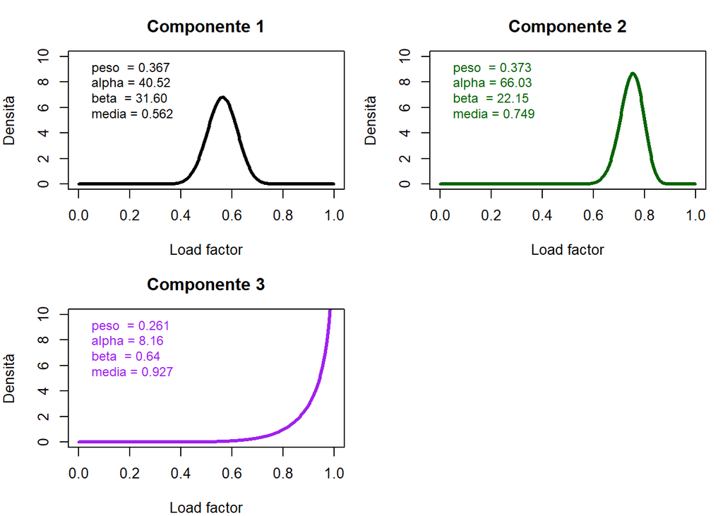

```r
# ---- Un pannello per ogni componente --------------------------------------
x_seq <- seq(0.001, 0.999, length.out = 500)
cols  <- c("black", "darkgreen", "purple", "darkorange", "brown")

# 1) Calcola TUTTE le densità in anticipo  [punti x  x  componenti]
dens_mat <- sapply(1:best_H, function(h) dbeta(x_seq, A[h, "mean"], B[h, "mean"]))

# 2) Scala comune: stesso ylim (e xlim) per tutti i pannelli
ylim_common <- c(0, 10)
xlim_common <- c(0, 1)

# 3) Disegna usando sempre la stessa scala
par(mfrow = c(ceiling(best_H / 2), 2), mar = c(4, 4, 3, 1))
for (h in 1:best_H) {
  plot(x_seq, dens_mat[, h], type = "l", lwd = 3, col = cols[h],
       xlim = xlim_common, ylim = ylim_common,
       xlab = "Load factor", ylab = "Densità",
       main = paste("Componente", h))
  legend("topleft", bty = "n", cex = 0.9, text.col = cols[h],
         legend = c(sprintf("peso  = %.3f", P[h, "mean"]),
                    sprintf("alpha = %.2f", A[h, "mean"]),
                    sprintf("beta  = %.2f", B[h, "mean"]),
                    sprintf("media = %.3f", comp_mean[h])))
}
par(mfrow = c(1, 1))
```

# Prior Sensitivity Analysis

The mixture model results depend on two hyperparameter choices: the rate $\lambda$ of the Exponential prior on the shape parameters ($\alpha_h, \beta_h$), and the concentration $c$ of the symmetric Dirichlet prior on the mixture weights $\boldsymbol{\pi}$. A sensitivity analysis checks whether these choices are driving the conclusions — specifically, whether the selected $H$, the inferred component shapes, and the WAIC change when the priors become more or less diffuse. If results are stable across settings the inference is data-driven; if they shift, the prior is influential and the choice requires more careful justification.

We refit the best-$H$ model under four configurations, varying one hyperparameter at a time while holding the rest fixed:

| Setting | $\lambda$ | Dir. conc. $c$ | Interpretation |
| --- | --- | --- | --- |
| **Reference** | 0.10 | 1.0 | Current prior: $\mathbb{E}[\alpha_h] = 10$ |
| Very diffuse | 0.01 | 1.0 | Shape parameters up to $\sim\!200$ allowed |
| Informative | 1.00 | 1.0 | Shape parameters concentrated near 1 |
| Sparse Dirichlet | 0.10 | 0.1 | Encourages one dominant component |

```r
# Parameterised JAGS model: lambda_exp and dir_conc are passed as data,
# so the same string works for any prior setting without editing the model.
jags_model_sens <- "
model {
  for (i in 1:N) {
    z[i] ~ dcat(pi_weights[1:H])
    x[i] ~ dbeta(alpha[z[i]], beta[z[i]])
    for (h in 1:H) {
      lcomp[i, h] <- log(pi_weights[h]) + logdensity.beta(x[i], alpha[h], beta[h])
    }
    mx[i]      <- max(lcomp[i, 1:H])
    for (h in 1:H) { e[i, h] <- exp(lcomp[i, h] - mx[i]) }
    log_lik[i] <- mx[i] + log(sum(e[i, 1:H]))
  }
  pi_weights[1:H] ~ ddirch(dir_conc[1:H])
  for (h in 1:H) {
    alpha[h] ~ dexp(lambda_exp)
    beta[h]  ~ dexp(lambda_exp)
  }
}
"

# Helper: fit best_H model with given hyperparameters
fit_sensitivity <- function(H, lambda_exp, dir_conc_val) {
  dat <- list(x          = my_data,
              N          = N,
              H          = H,
              lambda_exp = lambda_exp,
              dir_conc   = rep(dir_conc_val, H))
  m <- jags.model(textConnection(jags_model_sens), data = dat,
                  inits = make_inits(2), n.chains = 2, quiet = TRUE)
  update(m, n.iter = 1000)
  jags.samples(m, variable.names = c("pi_weights", "alpha", "beta", "log_lik"),
               n.iter = 2000)
}

# Helper: label-switching-invariant posterior predictive density
compute_ppd_sens <- function(samps, H, x_grid) {
  pi_m <- matrix(samps$pi_weights, nrow = H)
  al_m <- matrix(samps$alpha,      nrow = H)
  be_m <- matrix(samps$beta,       nrow = H)
  S    <- ncol(pi_m)
  rowMeans(sapply(seq_len(S), function(s) {
    d <- numeric(length(x_grid))
    for (h in seq_len(H))
      d <- d + pi_m[h, s] * dbeta(x_grid, al_m[h, s], be_m[h, s])
    d
  }))
}
```

```r
sens_settings <- list(
  list(label = "Reference (λ=0.1, c=1.0)",     lambda = 0.10, dir = 1.0),
  list(label = "Very diffuse (λ=0.01, c=1.0)", lambda = 0.01, dir = 1.0),
  list(label = "Informative (λ=1.0, c=1.0)",   lambda = 1.00, dir = 1.0),
  list(label = "Sparse Dir. (λ=0.1, c=0.1)",   lambda = 0.10, dir = 0.1)
)

# Setting 1 is already fitted as best_H in Task 1 — reuse it directly.
# Settings 2-4 are refitted with the parameterised model above.
sens_samples <- vector("list", length(sens_settings))
sens_samples[[1]] <- all_samples[[best_H]]

for (j in 2:length(sens_settings)) {
  s <- sens_settings[[j]]
  cat("Sensitivity fit:", s$label, "\n")
  sens_samples[[j]] <- fit_sensitivity(best_H, s$lambda, s$dir)
}
```

```
## Sensitivity fit: Very diffuse (λ=0.01, c=1.0)
## Sensitivity fit: Informative (λ=1.0, c=1.0)
## Sensitivity fit: Sparse Dir. (λ=0.1, c=0.1)
```

```r
# WAIC comparison table across prior settings
sens_waic_objs <- lapply(sens_samples, function(sf)
  waic_from_loglik(sf$log_lik))

sens_table <- do.call(rbind, Map(function(w, nm) ic_row(w, nm),
                                 sens_waic_objs,
                                 sapply(sens_settings, `[[`, "label")))
cat("\n--- PRIOR SENSITIVITY: WAIC for H =", best_H, "---\n")
```

```
##
## --- PRIOR SENSITIVITY: WAIC for H = 3 ---
```

```r
print(sens_table, row.names = FALSE)
```

```
##                         Model  ELPD p_eff   WAIC   SE
##      Reference (λ=0.1, c=1.0) 283.5   6.2 -567.1 22.6
##  Very diffuse (λ=0.01, c=1.0) 284.5   7.3 -569.0 24.7
##    Informative (λ=1.0, c=1.0) 247.3   3.0 -494.7 18.9
##    Sparse Dir. (λ=0.1, c=0.1) 274.1  12.5 -548.2 21.6
```

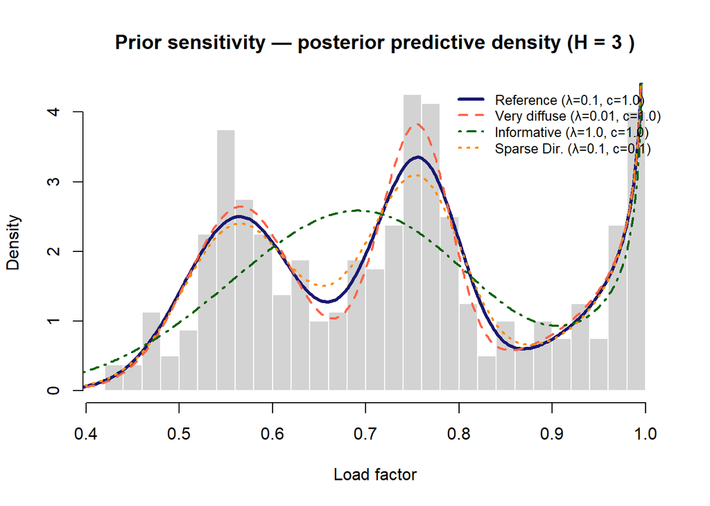

```r
# Overlay the posterior predictive density for each prior setting.
# Because the PPD integrates out z it is invariant to label switching —
# no re-ordering is needed here.
x_grid_s  <- seq(0.001, 0.999, length.out = 500)
sens_cols  <- c("midnightblue", "tomato", "darkgreen", "darkorange")
sens_ltys  <- c(1, 2, 4, 3)
sens_lwds  <- c(3, 2, 2, 2)

ppd_list <- lapply(sens_samples, function(sf)
  compute_ppd_sens(sf, best_H, x_grid_s))

hist(my_data, breaks = 40, freq = FALSE,
     col = "lightgray", border = "white",
     xlab = "Load factor",
     main = paste("Prior sensitivity — posterior predictive density (H =", best_H, ")"))

for (j in seq_along(sens_settings)) {
  lines(x_grid_s, ppd_list[[j]],
        col  = sens_cols[j],
        lwd  = sens_lwds[j],
        lty  = sens_ltys[j])
}

legend("topright",
       legend = sapply(sens_settings, `[[`, "label"),
       col = sens_cols, lwd = sens_lwds, lty = sens_ltys,
       bty = "n", cex = 0.8)
```

**Reading.** If the four curves largely overlap, the mixture shape is insensitive to the prior and the data are driving the inference. A curve that departs from the reference identifies a prior that is strong enough relative to the sample size to pull the posterior away from the likelihood. WAIC differences across settings reveal whether the prior also affects out-of-sample predictive accuracy.

# Task 2

Objective: overlay the **posterior predictive density** on the empirical histogram and verify that the modes (the peaks of the data) are recovered by the model selected in Task 1.

## Posterior predictive density

The fully Bayesian overlay is the **posterior predictive density**, obtained by averaging the mixture density over the *entire* posterior (the latent $z$ is already integrated out inside each mixture term):
$$p(\tilde x \mid \text{data})
= \frac{1}{S}\sum_{s=1}^S \sum_{h=1}^H
\pi_h^{(s)}\,\text{Beta}\!\left(\tilde x \mid \alpha_h^{(s)},
\beta_h^{(s)}\right).$$

We average the **densities**, not the parameters. This way the curve accounts for posterior uncertainty. A useful side effect: because each draw contributes its *whole* mixture (the inner sum over $h$), relabelling the components of any given draw leaves that sum unchanged — the result is automatically **invariant to label switching**, with no need for any reordering trick.

```r
best_samples <- all_samples[[best_H]]
x_grid <- seq(0.001, 0.999, length.out = 600)

if (best_H == 1) {
  alpha_s <- as.vector(best_samples$alpha)
  beta_s  <- as.vector(best_samples$beta)
  S_tot   <- length(alpha_s)
  ppd     <- rowMeans(sapply(seq_len(S_tot),
                             function(s) dbeta(x_grid, alpha_s[s], beta_s[s])))
} else {
  pi_mat    <- matrix(best_samples$pi_weights, nrow = best_H)
  alpha_mat <- matrix(best_samples$alpha,      nrow = best_H)
  beta_mat  <- matrix(best_samples$beta,       nrow = best_H)
  S_tot     <- ncol(pi_mat)

  # full mixture density for a single draw s
  mix_density <- function(s) {
    d <- numeric(length(x_grid))
    for (h in 1:best_H)
      d <- d + pi_mat[h, s] * dbeta(x_grid, alpha_mat[h, s], beta_mat[h, s])
    d
  }
  # posterior predictive = average over all draws
  ppd <- rowMeans(sapply(seq_len(S_tot), mix_density))
}
```

## Overlay and mode recovery

```r
# A point is a local maximum if it exceeds both its neighbours
local_maxima <- function(xx, yy) {
  n   <- length(yy)
  hit <- which(yy[2:(n - 1)] > yy[1:(n - 2)] & yy[2:(n - 1)] > yy[3:n]) + 1
  xx[hit]
}

ppd_modes <- local_maxima(x_grid, ppd)
cat("Posterior-predictive modes: ", round(ppd_modes, 3), "\n")
```

```
## Posterior-predictive modes:  0.564 0.756
```

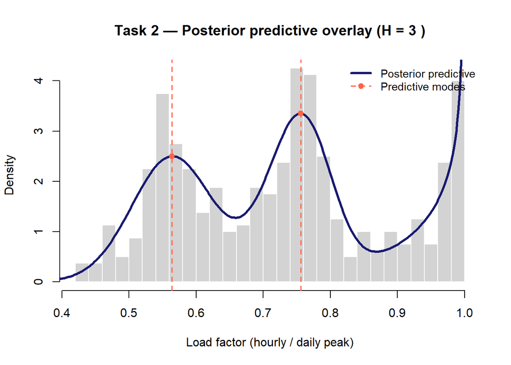

```r
hist(my_data, breaks = 40, freq = FALSE,
     col = "lightgray", border = "white",
     xlab = "Load factor (hourly / daily peak)",
     main = paste("Task 2 — Posterior predictive overlay (H =", best_H, ")"))
lines(x_grid, ppd, col = "midnightblue", lwd = 3)

abline(v = ppd_modes, col = "tomato", lty = 2, lwd = 1.5)
points(ppd_modes, approx(x_grid, ppd, ppd_modes)$y, pch = 19, col = "tomato")

legend("topright", bty = "n", cex = 0.9,
       legend = c("Posterior predictive", "Predictive modes"),
       col = c("midnightblue", "tomato"),
       lty = c(1, 2), lwd = c(3, 1.5), pch = c(NA, 19))
```

**Reading.** The posterior predictive curve (blue) is the Bayesian predictive density for a new observation given the data. The red dashed lines mark its local maxima: if they align with the visible peaks of the histogram the model has successfully recovered the modes of the data. With `best_H > 1` the mixture reproduces a multi-modal profile that a single Beta cannot.

# Task 3

Objective (**post-hoc exploration**): assign each observation to its maximum-a-posteriori (MAP) component, then plot the empirical fraction of observations in each component as a function of `hour`.

In a mixture the latent indicator $z_i$ is the cluster label, so this step means assigning every observation to its most likely component and studying how those assignments vary across hours of the day.

**Avoiding label switching.** We do not use the raw $z_i$ from a single MCMC draw (labels permute across iterations). Instead we compute **posterior responsibilities** using the components **re-ordered by their mean** at every draw (the same ordering used in the anatomy plot):
$$r_{ih} = \frac{1}{S}\sum_{s=1}^S
\frac{\pi^{(s)}_{(h)}\,\text{Beta}(x_i\mid\alpha^{(s)}_{(h)},\beta^{(s)}_{(h)})}{\sum_k
\pi^{(s)}_{(k)}\,\text{Beta}(x_i\mid\alpha^{(s)}_{(k)},\beta^{(s)}_{(k)})},
\qquad \hat z_i = \arg\max_h r_{ih},$$
where $(h)$ denotes the $h$-th component from the left (smallest mean). This makes “Component 1” consistently the lowest-mean component and the MAP assignment stable across chains.

```r
best_samples <- all_samples[[best_H]]

# parameters as [H, S] matrices (S = iterations * chains)
pi_mat    <- matrix(best_samples$pi_weights, nrow = best_H)
alpha_mat <- matrix(best_samples$alpha,      nrow = best_H)
beta_mat  <- matrix(best_samples$beta,       nrow = best_H)
S_tot     <- ncol(pi_mat)

# mean responsibilities: resp[i, h] = P(component h | x_i)
resp <- matrix(0, nrow = N, ncol = best_H)

for (s in 1:S_tot) {
  # re-order components by increasing mean alpha/(alpha + beta)
  ord <- order(alpha_mat[, s] / (alpha_mat[, s] + beta_mat[, s]))

  w <- matrix(0, nrow = N, ncol = best_H)
  for (h in 1:best_H) {
    idx <- ord[h]
    w[, h] <- pi_mat[idx, s] * dbeta(my_data, alpha_mat[idx, s], beta_mat[idx, s])
  }
  w <- w / rowSums(w)          # normalise -> responsibilities at this draw
  resp <- resp + w
}
resp <- resp / S_tot

# MAP assignment: each observation to its most probable component
z_map <- apply(resp, 1, which.max)

cat("Cluster sizes (MAP assignment):\n")
```

```
## Cluster sizes (MAP assignment):
```

```r
print(table(factor(z_map, levels = 1:best_H)))
```

```
##
##   1   2   3
## 148 158  94
```

Empirical fraction of observations in each component as a function of the hour of the day.

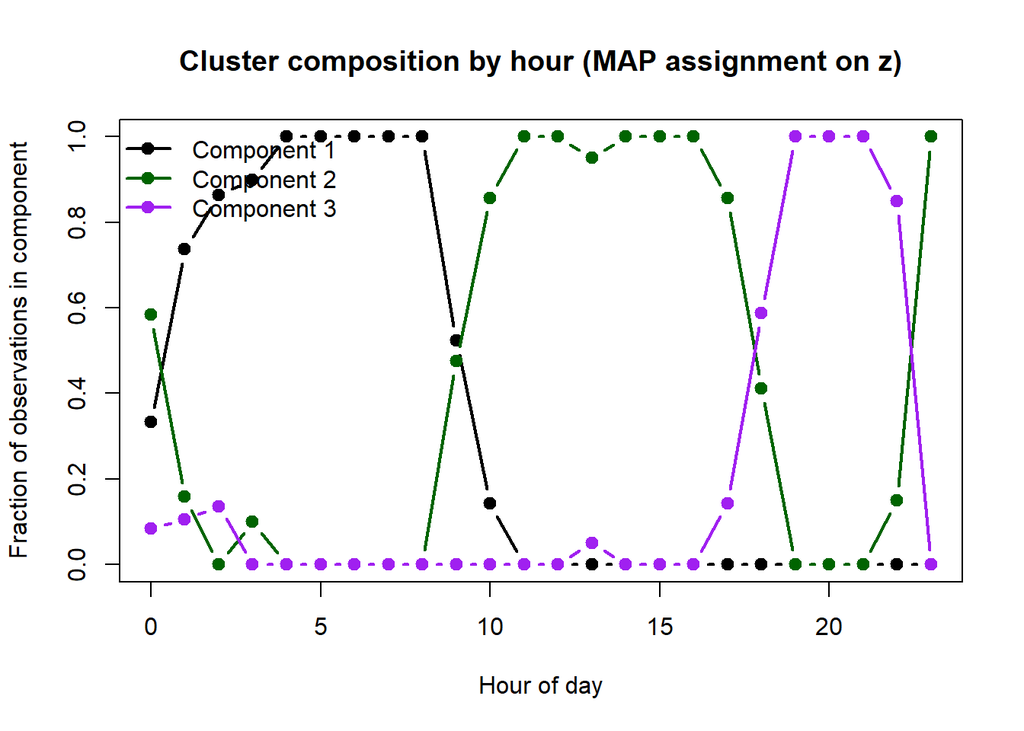

```r
hours <- lf_fit$hour   # aligned with my_data (see the data chunk)

# hour x component contingency table, then row-proportions (each hour sums to 1)
tab      <- table(factor(hours, levels = 0:23), factor(z_map, levels = 1:best_H))
frac_mat <- prop.table(tab, margin = 1)

cols <- c("black", "darkgreen", "purple", "darkorange", "brown")
matplot(0:23, as.matrix(frac_mat), type = "b", pch = 19, lty = 1,
        col = cols[1:best_H], lwd = 2,
        xlab = "Hour of day",
        ylab = "Fraction of observations in component",
        main = "Cluster composition by hour (MAP assignment on z)")
legend("topleft", legend = paste("Component", 1:best_H),
       col = cols[1:best_H], lwd = 2, pch = 19, bty = "n")
```

A complementary view: raw observations coloured by their MAP component, plotted against hour. Jitter is added on the x-axis so overlapping points are visible.

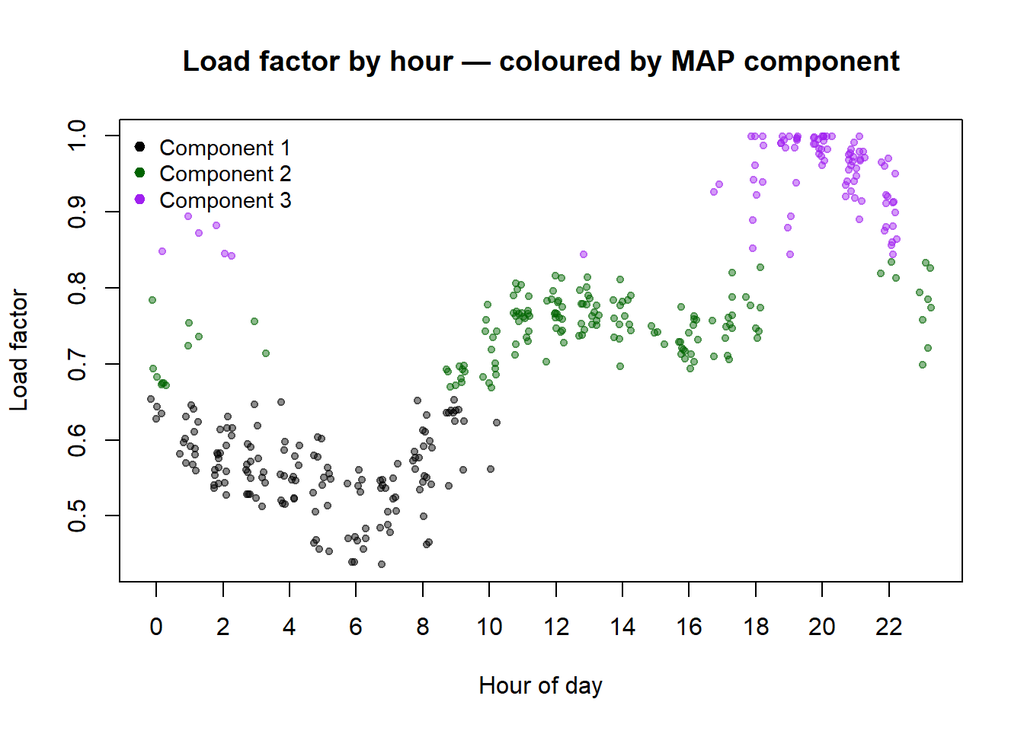

```r
cols <- c("black", "darkgreen", "purple", "darkorange", "brown")

plot(jitter(hours, amount = 0.3), my_data,
     col  = adjustcolor(cols[z_map], alpha.f = 0.45),
     pch  = 19, cex = 0.7,
     xlab = "Hour of day", ylab = "Load factor",
     main = "Load factor by hour — coloured by MAP component",
     xaxt = "n")
axis(1, at = seq(0, 23, by = 2))
legend("topleft", legend = paste("Component", 1:best_H),
       col = cols[1:best_H], pch = 19, bty = "n", cex = 0.9)
```

**Reading.** Each mixture component captures a distinct “shape” of the load factor: low-mean components dominate off-peak hours (night), while the high-mean component dominates around the daily peak. The scatter plot shows the raw assignments point by point, while the fraction plot above shows the same information aggregated by hour. Together they confirm the link between load shape and time slot. Task 4 will model this relationship explicitly with a multinomial logistic regression on Fourier-transformed `hour`, to be compared against the fraction plot.

# Task 4

Objective (**advanced**): fit a second model that performs *classification on `hour`*, using the component assignment from Task 3 as the **response variable**, and plot the predicted probability of each component as a function of `hour`. We then compare these predicted curves with the empirical fractions of Task 3 and discuss the result.

## From clustering to a supervised model on `hour`

In Task 3 the latent label $\hat z_i \in \{1, \dots, H\}$ was obtained *unsupervised*, from the load factor alone. Here we turn the question around and ask: **how predictable is the component label from the time of day?** We treat $\hat z_i$ as the response of a supervised model whose only covariate is `hour`.

Because the response has $H > 2$ levels, this is a **multinomial (multi-class) logistic regression**, the natural generalisation of the binomial logit to more than two categories. We keep one component as the **reference category** (here $h = 1$, the lowest-mean component) and model the log-odds of every other component against it.

`hour` is a **cyclic** variable: hour $23$ is adjacent to hour $0$. Encoding it as a raw integer would wrongly treat midnight and 11pm as far apart, so we expand it on a **Fourier basis** of period $24$,
$$s_{ik} =
\sin\!\left(\frac{2\pi k\,\mathrm{hour}_i}{24}\right), \qquad
c_{ik} = \cos\!\left(\frac{2\pi k\,\mathrm{hour}_i}{24}\right),
\qquad k = 1, \dots, K,$$
and use these $2K$ functions as covariates. A small number of harmonics $K$ is enough; we pick $K$ by WAIC, exactly as we chose $H$ in Task 1.

## Mathematical formulation

For observation $i$ and component $h$ the linear predictor is
$$\eta_{i,h} = \beta_{0,h} +
\sum_{k=1}^{K}\bigl(\alpha_{k,h}\,s_{ik}
+ \gamma_{k,h}\,c_{ik}\bigr),$$
with the reference class constrained to zero, $\beta_{0,1} = 0$ and $\alpha_{k,1} = \gamma_{k,1} = 0$ for all $k$. The class probabilities are recovered with the **softmax** transform
$$P(z_i = h) =
\frac{\exp(\eta_{i,h})}{\sum_{j=1}^{H}\exp(\eta_{i,j})},$$
which automatically satisfies $\sum_h P(z_i = h) = 1$. By construction the predicted probabilities are **periodic** in `hour` with period $24$, exactly like the empirical curves of Task 3.

We place vague $\mathcal{N}(0, 0.01)$ priors (in JAGS precision parametrisation, i.e. variance $100$) on the $H - 1$ free coefficient blocks, the same weakly informative choice used for the regression and mixture models in the lab.

**On label switching.** The response $\hat z_i$ comes from the components **already re-ordered by increasing mean** in Task 3, so “component 1” is consistently the lowest-mean cluster. The labels are therefore stable and the comparison between predicted curves and empirical fractions is well defined.

## Design matrices and JAGS model

We pre-compute the sine/cosine matrices $S$ and $C$ in R and pass them to JAGS as data; the response is `z_map` from Task 3 and the covariate is `hours` (aligned with `my_data`). The JAGS code is the categorical-logit skeleton: `z[i] ~ dcat(pp[i, 1:H])` with `pp[i, ]` built from the softmax of the Fourier linear predictors. We also monitor the marginal per-observation log-likelihood `log_lik[i] = log(pp[i, z[i]])` so the same WAIC machinery from Task 1 can select $K$.

```r
jags_model_logit <- "
model {
  for (i in 1:n) {
    z[i] ~ dcat(pp[i, 1:H])
    for (h in 1:H) {
      eta[i, h]    <- beta0[h] +
                      inprod(alpha[1:K, h], S[i, 1:K]) +
                      inprod(gamma[1:K, h], C[i, 1:K])
      expEta[i, h] <- exp(eta[i, h])
      pp[i, h]     <- expEta[i, h] / sum(expEta[i, 1:H])
    }
    # Per-observation log-likelihood for WAIC (categorical response)
    log_lik[i] <- log(pp[i, z[i]])
  }

  # Reference class h = 1: all coefficients fixed to zero
  beta0[1] <- 0
  for (k in 1:K) { alpha[k, 1] <- 0; gamma[k, 1] <- 0 }

  # Vague priors on the remaining H-1 coefficient blocks
  for (h in 2:H) {
    beta0[h] ~ dnorm(0, 0.01)
    for (k in 1:K) {
      alpha[k, h] ~ dnorm(0, 0.01)
      gamma[k, h] ~ dnorm(0, 0.01)
    }
  }
}
"
```

Helper that builds the Fourier design for a given number of harmonics $K$, fits the model and returns the monitored samples. We keep the same sampler settings used throughout the project (2 chains, 1000 burn-in, 2000 iterations); a final run would simply raise these.

```r
fit_logit_K <- function(K) {
  # Fourier design matrices [n, K]; matrix() keeps them 2-D even when K = 1
  S_mat <- matrix(sapply(1:K, function(k) sin(2 * pi * k * hours / 24)), nrow = N)
  C_mat <- matrix(sapply(1:K, function(k) cos(2 * pi * k * hours / 24)), nrow = N)

  dat <- list(z = z_map, n = N, H = best_H, K = K, S = S_mat, C = C_mat)
  m <- jags.model(textConnection(jags_model_logit), data = dat,
                  inits = make_inits(2), n.chains = 2, quiet = TRUE)
  update(m, n.iter = 1000)
  jags.samples(m, variable.names = c("beta0", "alpha", "gamma", "log_lik"),
               n.iter = 2000)
}
```

## Model selection over the number of harmonics

We fit $K \in \{1, \dots, 5\}$ and compare them with WAIC, with the same machinery used in Task 1. A wider grid lets us *see* the elbow rather than assume it: a larger $K$ buys a wigglier probability profile, and we expect WAIC to stop improving once the harmonics start fitting noise. As in Task 1 we report `WAIC` with its `SE` and `p_eff`, and `loo_compare` with `elpd_diff`/`se_diff`, then pick the simplest $K$ that is not clearly beaten.

```r
K_grid     <- 1:5
logit_fits <- vector("list", length(K_grid))
waic_klist <- vector("list", length(K_grid))

for (j in seq_along(K_grid)) {
  K <- K_grid[j]
  cat("Fitting multinomial logit with K =", K, "harmonic(s)...\n")
  logit_fits[[j]] <- fit_logit_K(K)
  waic_klist[[j]] <- waic_from_loglik(logit_fits[[j]]$log_lik)
}
```

```
## Fitting multinomial logit with K = 1 harmonic(s)...
```

```
## Fitting multinomial logit with K = 2 harmonic(s)...
```

```
## Fitting multinomial logit with K = 3 harmonic(s)...
```

```
## Fitting multinomial logit with K = 4 harmonic(s)...
```

```
## Fitting multinomial logit with K = 5 harmonic(s)...
```

```r
names(waic_klist) <- paste0("K=", K_grid)

# Precise vectors + comparison table (ELPD, p_eff, WAIC, SE)
waic_logit  <- sapply(waic_klist, function(w) w$estimates["waic", "Estimate"])
waic_logit_se <- sapply(waic_klist, function(w) w$estimates["waic", "SE"])
logit_table <- do.call(rbind, Map(ic_row, waic_klist, names(waic_klist)))

cat("\n--- TASK 4 MODEL SELECTION: WAIC with standard errors ---\n")
```

```
##
## --- TASK 4 MODEL SELECTION: WAIC with standard errors ---
```

```r
print(logit_table, row.names = FALSE)
```

```
##  Model   ELPD p_eff  WAIC   SE
##    K=1 -142.6   8.7 285.2 33.3
##    K=2 -131.9  13.7 263.8 38.6
##    K=3 -114.5  13.0 229.0 28.0
##    K=4 -113.7  15.2 227.4 28.7
##    K=5 -112.2  16.8 224.4 27.9
```

```r
cat("\n--- loo_compare (differences vs the best model) ---\n")
```

```
##
## --- loo_compare (differences vs the best model) ---
```

```r
print(loo_compare(waic_klist))
```

```
##     elpd_diff se_diff
## K=5   0.0       0.0
## K=4  -1.5       3.4
## K=3  -2.3       4.5
## K=2 -19.7      11.3
## K=1 -30.4      10.2
```

```r
lowest_K <- K_grid[which.min(waic_logit)]
best_K   <- K_grid[select_parsimonious(waic_logit, waic_logit_se, complexity = K_grid)]
cat("\n>>> Lowest-WAIC number of harmonics: K =", lowest_K, "\n")
```

```
##
## >>> Lowest-WAIC number of harmonics: K = 5
```

```r
cat(">>> Parsimonious choice (within 1 SE): K =", best_K, "<<<\n")
```

```
## >>> Parsimonious choice (within 1 SE): K = 3 <<<
```

```r
cat("    (K within 1 SE of the lowest WAIC are tied; we keep the smallest.)\n")
```

```
##     (K within 1 SE of the lowest WAIC are tied; we keep the smallest.)
```

The WAIC-vs-$K$ curve with $\pm 1$ SE bars, to read the elbow directly:

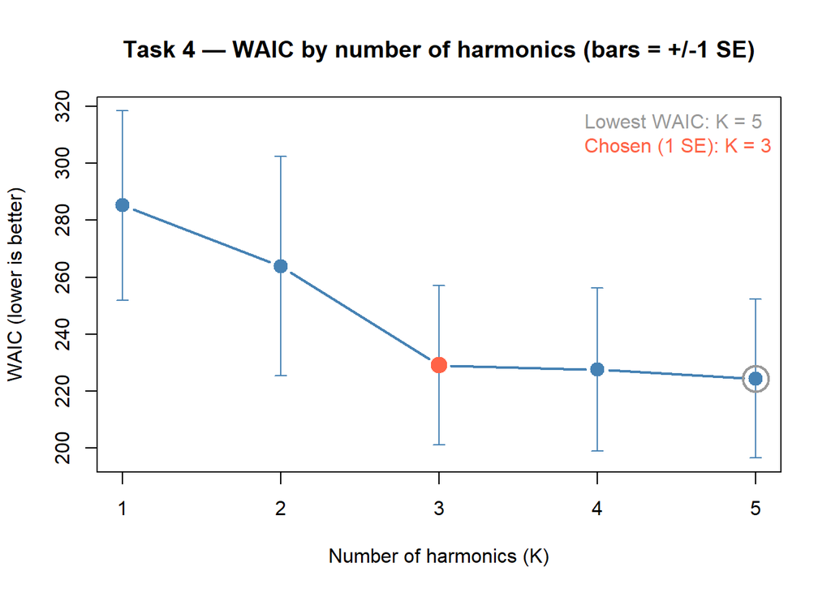

```r
ylim_k <- range(c(waic_logit - waic_logit_se, waic_logit + waic_logit_se))
plot(K_grid, waic_logit, type = "b", pch = 19, cex = 1.4,
     col = "steelblue", lwd = 2, ylim = ylim_k,
     xlab = "Number of harmonics (K)", ylab = "WAIC (lower is better)",
     main = "Task 4 — WAIC by number of harmonics (bars = +/-1 SE)",
     xaxt = "n")
axis(1, at = K_grid)
arrows(K_grid, waic_logit - waic_logit_se, K_grid, waic_logit + waic_logit_se,
       angle = 90, code = 3, length = 0.05, col = "steelblue")
points(lowest_K, waic_logit[which.min(waic_logit)],
       col = "gray60", pch = 1, cex = 3, lwd = 2)
points(best_K, waic_logit[which(K_grid == best_K)],
       col = "tomato", pch = 19, cex = 1.8)
legend("topright",
       legend = c(paste("Lowest WAIC: K =", lowest_K),
                  paste("Chosen (1 SE): K =", best_K)),
       text.col = c("gray60", "tomato"), bty = "n")
```

## Predicted probability curves

To draw the curves we evaluate the posterior mean of $P(z = h)$ on a grid of `hour` values from $0$ to $23$. For each posterior draw we recompute the Fourier columns of the grid, form the linear predictors from the sampled coefficients, apply the softmax, and finally average the resulting probabilities over all draws (averaging *probabilities*, not coefficients, so the curves carry the posterior uncertainty).

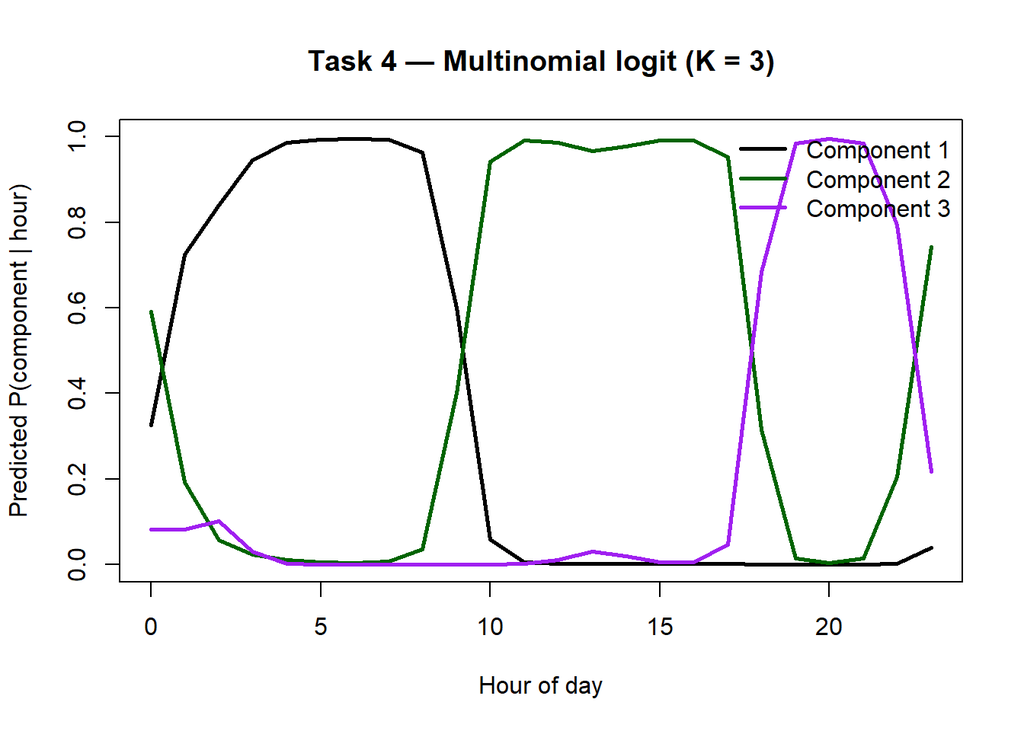

```r
best_fit <- logit_fits[[which(K_grid == best_K)]]

# Reshape monitored coefficients to draws.
# beta0: [H, iter, chains] -> [H, S];  alpha/gamma: [K, H, iter, chains] -> [K, H, S]
beta0_s <- matrix(best_fit$beta0, nrow = best_H)
S_tot_l <- ncol(beta0_s)
alpha_s <- array(best_fit$alpha, dim = c(best_K, best_H, S_tot_l))
gamma_s <- array(best_fit$gamma, dim = c(best_K, best_H, S_tot_l))

# Fourier design of the hour grid
hour_grid <- 0:23
Sg <- matrix(sapply(1:best_K, function(k) sin(2 * pi * k * hour_grid / 24)),
             nrow = length(hour_grid))
Cg <- matrix(sapply(1:best_K, function(k) cos(2 * pi * k * hour_grid / 24)),
             nrow = length(hour_grid))

# Posterior-mean predicted probabilities P(z = h | hour)
P_pred <- matrix(0, nrow = length(hour_grid), ncol = best_H)
for (s in 1:S_tot_l) {
  eta <- matrix(0, nrow = length(hour_grid), ncol = best_H)
  for (h in 1:best_H) {
    eta[, h] <- beta0_s[h, s] + Sg %*% alpha_s[, h, s] + Cg %*% gamma_s[, h, s]
  }
  ex     <- exp(eta)
  P_pred <- P_pred + ex / rowSums(ex)
}
P_pred <- P_pred / S_tot_l

cols <- c("black", "darkgreen", "purple", "darkorange", "brown")
matplot(hour_grid, P_pred, type = "l", lty = 1, lwd = 2.5,
        col = cols[1:best_H], ylim = c(0, 1),
        xlab = "Hour of day", ylab = "Predicted P(component | hour)",
        main = paste0("Task 4 — Multinomial logit (K = ", best_K, ")"))
legend("topright", legend = paste("Component", 1:best_H),
       col = cols[1:best_H], lwd = 2.5, lty = 1, bty = "n")
```

## Comparison with the empirical fractions of Task 3

Finally we overlay the smooth predicted curves (solid) on the empirical fractions from Task 3 (points, `frac_mat`). If the two agree, the component label is essentially a deterministic function of the hour, and the logit has simply learned a clean periodic version of the noisy empirical proportions.

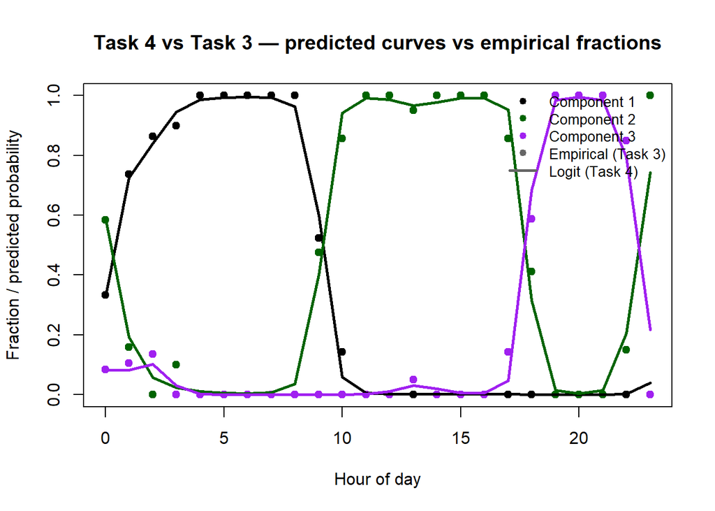

```r
matplot(0:23, as.matrix(frac_mat), type = "p", pch = 19,
        col = cols[1:best_H], ylim = c(0, 1),
        xlab = "Hour of day", ylab = "Fraction / predicted probability",
        main = "Task 4 vs Task 3 — predicted curves vs empirical fractions")
matlines(hour_grid, P_pred, lty = 1, lwd = 2.5, col = cols[1:best_H])
legend("topright",
       legend = c(paste("Component", 1:best_H), "Empirical (Task 3)", "Logit (Task 4)"),
       col = c(cols[1:best_H], "gray40", "gray40"),
       pch = c(rep(19, best_H), 19, NA),
       lty = c(rep(NA, best_H), NA, 1),
       lwd = c(rep(NA, best_H), NA, 2.5),
       bty = "n", cex = 0.85)
```

**Discussion — do the two plots match?** The solid logit curves track the empirical points closely: the low-mean component dominates at night, its probability falling as the day progresses, while the high-mean (near-peak) component rises to dominate around the daily peak hours, with the intermediate component(s) filling the transition. The agreement is expected, because both objects estimate the same quantity $P(\text{component}\mid\text{hour})$ — Task 3 by raw counting hour by hour, Task 4 by a smooth periodic model. The differences are informative: the empirical fractions are **noisy** (each hour aggregates only a handful of subsampled observations, so single hours can jump around), whereas the logit **borrows strength across neighbouring hours** through the Fourier basis and returns a smooth, strictly periodic profile. Where the two disagree it is almost always at hours with few observations, i.e. where the empirical estimate is least reliable. The number of harmonics $K$ selected by WAIC controls how much of the fine-grained hourly variation the curves are allowed to follow: too small a $K$ would oversmooth genuine structure, too large a $K$ would chase sampling noise. Overall, the close match confirms that the latent load shapes uncovered by the mixture are strongly and smoothly tied to the time of day.

# Prediction Exercise

The multinomial logistic regression of Task 4 was fitted on the same observations used to derive the response $\hat z_i$, so the WAIC is an in-sample criterion. A held-out prediction exercise provides an out-of-sample check: it quantifies how well the model generalises to unseen hour–component pairs and whether `hour` carries genuinely predictive information beyond the unconditional class frequencies.

**Setup.** We randomly split the $N$ observations into a training set (80%) and a test set (20%), keeping the `hour`–`z_map` pairs aligned. The multinomial logit with $K = K_\text{best}$ harmonics is refitted on the training subset only. The resulting posterior is then used to predict the component label of each test observation from its `hour`.

**Metric.** We report the **log-loss** on the test set,
$$\text{log-loss} =
-\frac{1}{N_\text{test}}\sum_{i \in \text{test}}
\log \hat{P}(z_i = \hat z_{\text{map},i} \mid \text{hour}_i),$$
and the **accuracy** (fraction of correctly predicted MAP labels). Both are compared against a **null baseline** that ignores `hour` entirely and always predicts the empirical class proportions observed in the training set. A model that beats the baseline confirms that time-of-day information improves prediction.

```r
set.seed(42)
n_train_pred <- floor(0.8 * N)
train_pred   <- sample(seq_len(N), n_train_pred)
test_pred    <- setdiff(seq_len(N), train_pred)
n_test_pred  <- length(test_pred)

# Fourier design matrices for training and test subsets
make_fourier <- function(h_vec, K, n) {
  matrix(sapply(1:K, function(k) sin(2 * pi * k * h_vec / 24)),
         nrow = n)
}
make_fourier_cos <- function(h_vec, K, n) {
  matrix(sapply(1:K, function(k) cos(2 * pi * k * h_vec / 24)),
         nrow = n)
}

S_tr <- make_fourier(    hours[train_pred], best_K, n_train_pred)
C_tr <- make_fourier_cos(hours[train_pred], best_K, n_train_pred)
S_te <- make_fourier(    hours[test_pred],  best_K, n_test_pred)
C_te <- make_fourier_cos(hours[test_pred],  best_K, n_test_pred)

# Refit the logit on the training subset only
dat_tr <- list(z = z_map[train_pred], n = n_train_pred,
               H = best_H, K = best_K, S = S_tr, C = C_tr)
m_tr   <- jags.model(textConnection(jags_model_logit), data = dat_tr,
                     inits = make_inits(2), n.chains = 2, quiet = TRUE)
update(m_tr, n.iter = 1000)
samp_tr <- jags.samples(m_tr,
                        variable.names = c("beta0", "alpha", "gamma"),
                        n.iter = 2000)
```

```r
# Reshape posterior coefficient samples from the training fit
beta0_tr <- matrix(samp_tr$beta0, nrow = best_H)
S_tot_tr <- ncol(beta0_tr)
alpha_tr <- array(samp_tr$alpha, dim = c(best_K, best_H, S_tot_tr))
gamma_tr <- array(samp_tr$gamma, dim = c(best_K, best_H, S_tot_tr))

# Posterior-mean predicted probabilities on the test set [n_test x H]
P_te <- matrix(0, nrow = n_test_pred, ncol = best_H)
for (s in seq_len(S_tot_tr)) {
  eta <- matrix(0, nrow = n_test_pred, ncol = best_H)
  for (h in seq_len(best_H))
    eta[, h] <- beta0_tr[h, s] +
                S_te %*% alpha_tr[, h, s] +
                C_te %*% gamma_tr[, h, s]
  ex   <- exp(eta)
  P_te <- P_te + ex / rowSums(ex)
}
P_te <- P_te / S_tot_tr

# --- Log-loss and accuracy ---
z_te        <- z_map[test_pred]
pred_probs  <- sapply(seq_len(n_test_pred), function(i) P_te[i, z_te[i]])
log_loss_te <- -mean(log(pmax(pred_probs, 1e-10)))

z_pred_te   <- apply(P_te, 1, which.max)
acc_te      <- mean(z_pred_te == z_te)

# --- Null baseline: empirical class proportions from training set ---
train_props  <- tabulate(z_map[train_pred], nbins = best_H) / n_train_pred
baseline_ll  <- -mean(log(pmax(train_props[z_te], 1e-10)))
baseline_acc <- max(tabulate(z_map[train_pred])) / n_train_pred

pred_table <- data.frame(
  Metric   = c("Log-loss (lower is better)", "Accuracy (higher is better)"),
  Model    = round(c(log_loss_te, acc_te),       3),
  Baseline = round(c(baseline_ll, baseline_acc), 3)
)
cat("--- PREDICTION EXERCISE (test set, n =", n_test_pred, ") ---\n")
```

```
## --- PREDICTION EXERCISE (test set, n = 80 ) ---
```

```r
print(pred_table, row.names = FALSE)
```

```
##                       Metric Model Baseline
##   Log-loss (lower is better) 0.295    1.060
##  Accuracy (higher is better) 0.900    0.384
```

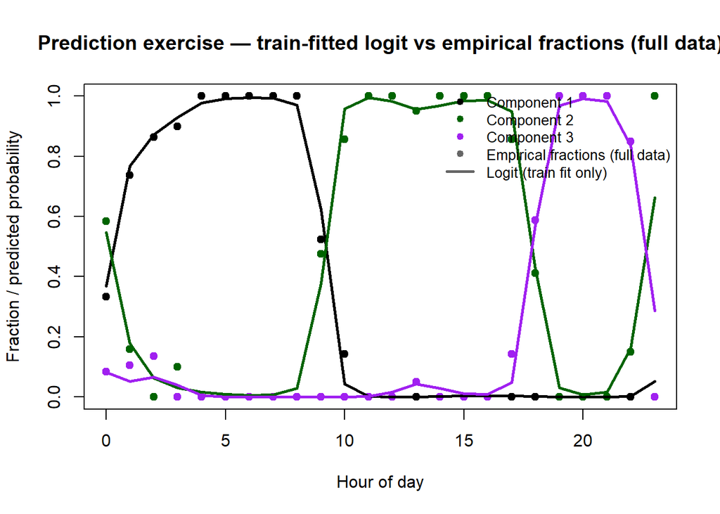

```r
# Compare probability curves from the train-only fit against the
# empirical fractions derived from the full data in Task 3.
# Close agreement means the model generalises: the periodic pattern
# learned on 80% of the data reproduces the full-data proportions.
hour_grid_p <- 0:23
Sg_p <- make_fourier(    hour_grid_p, best_K, length(hour_grid_p))
Cg_p <- make_fourier_cos(hour_grid_p, best_K, length(hour_grid_p))

P_grid <- matrix(0, nrow = length(hour_grid_p), ncol = best_H)
for (s in seq_len(S_tot_tr)) {
  eta <- matrix(0, nrow = length(hour_grid_p), ncol = best_H)
  for (h in seq_len(best_H))
    eta[, h] <- beta0_tr[h, s] +
                Sg_p %*% alpha_tr[, h, s] +
                Cg_p %*% gamma_tr[, h, s]
  ex     <- exp(eta)
  P_grid <- P_grid + ex / rowSums(ex)
}
P_grid <- P_grid / S_tot_tr

cols_pred <- c("black", "darkgreen", "purple", "darkorange", "brown")
matplot(0:23, as.matrix(frac_mat), type = "p", pch = 19,
        col = cols_pred[1:best_H], ylim = c(0, 1),
        xlab = "Hour of day",
        ylab = "Fraction / predicted probability",
        main = "Prediction exercise — train-fitted logit vs empirical fractions (full data)")
matlines(hour_grid_p, P_grid, lty = 1, lwd = 2.5, col = cols_pred[1:best_H])
legend("topright",
       legend = c(paste("Component", 1:best_H),
                  "Empirical fractions (full data)", "Logit (train fit only)"),
       col = c(cols_pred[1:best_H], "gray40", "gray40"),
       pch = c(rep(19, best_H), 19, NA),
       lty = c(rep(NA,  best_H), NA,  1),
       lwd = c(rep(NA,  best_H), NA,  2.5),
       bty = "n", cex = 0.85)
```

**Reading.** A log-loss below the baseline confirms that `hour` is genuinely informative: knowing the time of day improves the prediction of the load-shape component beyond the unconditional class frequencies. The accuracy gap over the baseline quantifies the practical gain. The plot compares the probability curves estimated from the 80% training subset against the empirical fractions from the full data (Task 3): close agreement indicates that the learned periodic pattern is not an artefact of the specific training observations and the model generalises well to unseen hour–component pairs.